# Uma análise sobre jogos da steam (até 2019)

```python
import pandas as pd
import numpy as np
import seaborn as sns
```

Aqui eu estou apenas definindo algumas questões estáticas na apresentação dos gráficos

```python
sns.set_style('whitegrid')
sns.set_palette('flare_r')
sns.color_palette('flare_r')
```

Afim de me aprofundar um pouco mais em data science, regressões e machine learning, baixei o conjunto de dados disponibilizado nesse link (por Nik Davis):  
https://www.kaggle.com/nikdavis/steam-store-games

Dentro do arquivo de download, haviam 6 arquivos .csv. Dessa forma, vou primeiro dar uma olhadinha em cada 1 deles para ter mais noção do tipo e variação de dados que tenho a disposição.

```python
df1 = pd.read_csv('Dados Brutos/steam.csv')
```

```python
df1.head()
```

|  | appid | name | release_date | english | developer | publisher | platforms | required_age | categories | genres | steamspy_tags | achievements | positive_ratings | negative_ratings | average_playtime | median_playtime | owners | price |
| --- | --- | --- | --- | --- | --- | --- | --- | --- | --- | --- | --- | --- | --- | --- | --- | --- | --- | --- |
| 0 | 10 | Counter-Strike | 2000-11-01 | 1 | Valve | Valve | windows;mac;linux | 0 | Multi-player;Online Multi-Player;Local Multi-P... | Action | Action;FPS;Multiplayer | 0 | 124534 | 3339 | 17612 | 317 | 10000000-20000000 | 7.19 |
| 1 | 20 | Team Fortress Classic | 1999-04-01 | 1 | Valve | Valve | windows;mac;linux | 0 | Multi-player;Online Multi-Player;Local Multi-P... | Action | Action;FPS;Multiplayer | 0 | 3318 | 633 | 277 | 62 | 5000000-10000000 | 3.99 |
| 2 | 30 | Day of Defeat | 2003-05-01 | 1 | Valve | Valve | windows;mac;linux | 0 | Multi-player;Valve Anti-Cheat enabled | Action | FPS;World War II;Multiplayer | 0 | 3416 | 398 | 187 | 34 | 5000000-10000000 | 3.99 |
| 3 | 40 | Deathmatch Classic | 2001-06-01 | 1 | Valve | Valve | windows;mac;linux | 0 | Multi-player;Online Multi-Player;Local Multi-P... | Action | Action;FPS;Multiplayer | 0 | 1273 | 267 | 258 | 184 | 5000000-10000000 | 3.99 |
| 4 | 50 | Half-Life: Opposing Force | 1999-11-01 | 1 | Gearbox Software | Valve | windows;mac;linux | 0 | Single-player;Multi-player;Valve Anti-Cheat en... | Action | FPS;Action;Sci-fi | 0 | 5250 | 288 | 624 | 415 | 5000000-10000000 | 3.99 |

```python
df1.shape
```

```
(27075, 18)
```

```python
df1.info()
```

```
<class 'pandas.core.frame.DataFrame'>
RangeIndex: 27075 entries, 0 to 27074
Data columns (total 18 columns):
 #   Column            Non-Null Count  Dtype
---  ------            --------------  -----
 0   appid             27075 non-null  int64
 1   name              27075 non-null  object
 2   release_date      27075 non-null  object
 3   english           27075 non-null  int64
 4   developer         27075 non-null  object
 5   publisher         27075 non-null  object
 6   platforms         27075 non-null  object
 7   required_age      27075 non-null  int64
 8   categories        27075 non-null  object
 9   genres            27075 non-null  object
 10  steamspy_tags     27075 non-null  object
 11  achievements      27075 non-null  int64
 12  positive_ratings  27075 non-null  int64
 13  negative_ratings  27075 non-null  int64
 14  average_playtime  27075 non-null  int64
 15  median_playtime   27075 non-null  int64
 16  owners            27075 non-null  object
 17  price             27075 non-null  float64
dtypes: float64(1), int64(8), object(9)
memory usage: 3.7+ MB
```

```python
df1.describe()
```

|  | appid | english | required_age | achievements | positive_ratings | negative_ratings | average_playtime | median_playtime | price |
| --- | --- | --- | --- | --- | --- | --- | --- | --- | --- |
| count | 2.707500e+04 | 27075.000000 | 27075.000000 | 27075.000000 | 2.707500e+04 | 27075.000000 | 27075.000000 | 27075.00000 | 27075.000000 |
| mean | 5.962035e+05 | 0.981127 | 0.354903 | 45.248864 | 1.000559e+03 | 211.027147 | 149.804949 | 146.05603 | 6.078193 |
| std | 2.508942e+05 | 0.136081 | 2.406044 | 352.670281 | 1.898872e+04 | 4284.938531 | 1827.038141 | 2353.88008 | 7.874922 |
| min | 1.000000e+01 | 0.000000 | 0.000000 | 0.000000 | 0.000000e+00 | 0.000000 | 0.000000 | 0.00000 | 0.000000 |
| 25% | 4.012300e+05 | 1.000000 | 0.000000 | 0.000000 | 6.000000e+00 | 2.000000 | 0.000000 | 0.00000 | 1.690000 |
| 50% | 5.990700e+05 | 1.000000 | 0.000000 | 7.000000 | 2.400000e+01 | 9.000000 | 0.000000 | 0.00000 | 3.990000 |
| 75% | 7.987600e+05 | 1.000000 | 0.000000 | 23.000000 | 1.260000e+02 | 42.000000 | 0.000000 | 0.00000 | 7.190000 |
| max | 1.069460e+06 | 1.000000 | 18.000000 | 9821.000000 | 2.644404e+06 | 487076.000000 | 190625.000000 | 190625.00000 | 421.990000 |

```python
df2 = pd.read_csv('Dados Brutos/steam_description_data.csv')
```

```python
df2.head(10)
```

|  | steam_appid | detailed_description | about_the_game | short_description |
| --- | --- | --- | --- | --- |
| 0 | 10 | Play the world's number 1 online action game. ... | Play the world's number 1 online action game. ... | Play the world's number 1 online action game. ... |
| 1 | 20 | One of the most popular online action games of... | One of the most popular online action games of... | One of the most popular online action games of... |
| 2 | 30 | Enlist in an intense brand of Axis vs. Allied ... | Enlist in an intense brand of Axis vs. Allied ... | Enlist in an intense brand of Axis vs. Allied ... |
| 3 | 40 | Enjoy fast-paced multiplayer gaming with Death... | Enjoy fast-paced multiplayer gaming with Death... | Enjoy fast-paced multiplayer gaming with Death... |
| 4 | 50 | Return to the Black Mesa Research Facility as ... | Return to the Black Mesa Research Facility as ... | Return to the Black Mesa Research Facility as ... |
| 5 | 60 | A futuristic action game that challenges your ... | A futuristic action game that challenges your ... | A futuristic action game that challenges your ... |
| 6 | 70 | Named Game of the Year by over 50 publications... | Named Game of the Year by over 50 publications... | Named Game of the Year by over 50 publications... |
| 7 | 80 | With its extensive Tour of Duty campaign, a ne... | With its extensive Tour of Duty campaign, a ne... | With its extensive Tour of Duty campaign, a ne... |
| 8 | 130 | Made by Gearbox Software and originally releas... | Made by Gearbox Software and originally releas... | Made by Gearbox Software and originally releas... |
| 9 | 220 | 1998. HALF-LIFE sends a shock through the game... | 1998. HALF-LIFE sends a shock through the game... | 1998. HALF-LIFE sends a shock through the game... |

```python
df2.shape
```

```
(27334, 4)
```

```python
df2.describe()
```

|  | steam_appid |
| --- | --- |
| count | 2.733400e+04 |
| mean | 5.982886e+05 |
| std | 2.512113e+05 |
| min | 1.000000e+01 |
| 25% | 4.030925e+05 |
| 50% | 6.019650e+05 |
| 75% | 8.011750e+05 |
| max | 1.069460e+06 |

```python
df3 = pd.read_csv('Dados Brutos/steam_media_data.csv')
```

```python
df3.head()
```

|  | steam_appid | header_image | screenshots | background | movies |
| --- | --- | --- | --- | --- | --- |
| 0 | 10 | https://steamcdn-a.akamaihd.net/steam/apps/10/... | [{'id': 0, 'path_thumbnail': 'https://steamcdn... | https://steamcdn-a.akamaihd.net/steam/apps/10/... | NaN |
| 1 | 20 | https://steamcdn-a.akamaihd.net/steam/apps/20/... | [{'id': 0, 'path_thumbnail': 'https://steamcdn... | https://steamcdn-a.akamaihd.net/steam/apps/20/... | NaN |
| 2 | 30 | https://steamcdn-a.akamaihd.net/steam/apps/30/... | [{'id': 0, 'path_thumbnail': 'https://steamcdn... | https://steamcdn-a.akamaihd.net/steam/apps/30/... | NaN |
| 3 | 40 | https://steamcdn-a.akamaihd.net/steam/apps/40/... | [{'id': 0, 'path_thumbnail': 'https://steamcdn... | https://steamcdn-a.akamaihd.net/steam/apps/40/... | NaN |
| 4 | 50 | https://steamcdn-a.akamaihd.net/steam/apps/50/... | [{'id': 0, 'path_thumbnail': 'https://steamcdn... | https://steamcdn-a.akamaihd.net/steam/apps/50/... | NaN |

```python
df4 = pd.read_csv('Dados Brutos/steam_requirements_data.csv')
```

```python
df4.head()
```

|  | steam_appid | pc_requirements | mac_requirements | linux_requirements | minimum | recommended |
| --- | --- | --- | --- | --- | --- | --- |
| 0 | 10 | {'minimum': '\r\n\t\t\t<p><strong>Minimum:</st... | {'minimum': 'Minimum: OS X Snow Leopard 10.6.... | {'minimum': 'Minimum: Linux Ubuntu 12.04, Dual... | 500 mhz processor, 96mb ram, 16mb video card, ... | NaN |
| 1 | 20 | {'minimum': '\r\n\t\t\t<p><strong>Minimum:</st... | {'minimum': 'Minimum: OS X Snow Leopard 10.6.... | {'minimum': 'Minimum: Linux Ubuntu 12.04, Dual... | 500 mhz processor, 96mb ram, 16mb video card, ... | NaN |
| 2 | 30 | {'minimum': '\r\n\t\t\t<p><strong>Minimum:</st... | {'minimum': 'Minimum: OS X Snow Leopard 10.6.... | {'minimum': 'Minimum: Linux Ubuntu 12.04, Dual... | 500 mhz processor, 96mb ram, 16mb video card, ... | NaN |
| 3 | 40 | {'minimum': '\r\n\t\t\t<p><strong>Minimum:</st... | {'minimum': 'Minimum: OS X Snow Leopard 10.6.... | {'minimum': 'Minimum: Linux Ubuntu 12.04, Dual... | 500 mhz processor, 96mb ram, 16mb video card, ... | NaN |
| 4 | 50 | {'minimum': '\r\n\t\t\t<p><strong>Minimum:</st... | {'minimum': 'Minimum: OS X Snow Leopard 10.6.... | {'minimum': 'Minimum: Linux Ubuntu 12.04, Dual... | 500 mhz processor, 96mb ram, 16mb video card, ... | NaN |

```python
df5 = pd.read_csv('Dados Brutos/steam_support_info.csv')
```

```python
df5.head()
```

|  | steam_appid | website | support_url | support_email |
| --- | --- | --- | --- | --- |
| 0 | 10 | NaN | http://steamcommunity.com/app/10 | NaN |
| 1 | 30 | http://www.dayofdefeat.com/ | NaN | NaN |
| 2 | 50 | NaN | https://help.steampowered.com | NaN |
| 3 | 70 | http://www.half-life.com/ | http://steamcommunity.com/app/70 | NaN |
| 4 | 80 | NaN | http://steamcommunity.com/app/80 | NaN |

```python
df6 = pd.read_csv('Dados Brutos/steamspy_tag_data.csv')
```

```python
df6.head()
```

|  | appid | 1980s | 1990s | 2.5d | 2d | 2d_fighter | 360_video | 3d | 3d_platformer | 3d_vision | ... | warhammer_40k | web_publishing | werewolves | western | word_game | world_war_i | world_war_ii | wrestling | zombies | e_sports |
| --- | --- | --- | --- | --- | --- | --- | --- | --- | --- | --- | --- | --- | --- | --- | --- | --- | --- | --- | --- | --- | --- |
| 0 | 10 | 144 | 564 | 0 | 0 | 0 | 0 | 0 | 0 | 0 | ... | 0 | 0 | 0 | 0 | 0 | 0 | 0 | 0 | 0 | 550 |
| 1 | 20 | 0 | 71 | 0 | 0 | 0 | 0 | 0 | 0 | 0 | ... | 0 | 0 | 0 | 0 | 0 | 0 | 0 | 0 | 0 | 0 |
| 2 | 30 | 0 | 0 | 0 | 0 | 0 | 0 | 0 | 0 | 0 | ... | 0 | 0 | 0 | 0 | 0 | 5 | 122 | 0 | 0 | 0 |
| 3 | 40 | 0 | 0 | 0 | 0 | 0 | 0 | 0 | 0 | 0 | ... | 0 | 0 | 0 | 0 | 0 | 0 | 0 | 0 | 0 | 0 |
| 4 | 50 | 0 | 77 | 0 | 0 | 0 | 0 | 0 | 0 | 0 | ... | 0 | 0 | 0 | 0 | 0 | 0 | 0 | 0 | 0 | 0 |

5 rows × 372 columns

Deu pra dar uma boa olhada nas bases. Provavelmente a mais útil pro que tenho em mente será a primeira mesmo, porém, acho que existe bastante espaço pra fazer algum tipo de nuvem de palavras com a segunda, que contém descrições dos jogos, e talvez dê pra ter uma noção de qual a configuração ideal de computador pra rodar jogos da steam usando essas informações da quarta base.

# Analisando o primeiro dataframe

É possível notar que, na primeira base, existe um campo de data. Ele está com a tipagem de 'object', porém, acredito que faça mais sentido avalia-lo como data.

```python
df = df1.copy()
```

```python
df.head()
```

|  | appid | name | release_date | english | developer | publisher | platforms | required_age | categories | genres | steamspy_tags | achievements | positive_ratings | negative_ratings | average_playtime | median_playtime | owners | price |
| --- | --- | --- | --- | --- | --- | --- | --- | --- | --- | --- | --- | --- | --- | --- | --- | --- | --- | --- |
| 0 | 10 | Counter-Strike | 2000-11-01 | 1 | Valve | Valve | windows;mac;linux | 0 | Multi-player;Online Multi-Player;Local Multi-P... | Action | Action;FPS;Multiplayer | 0 | 124534 | 3339 | 17612 | 317 | 10000000-20000000 | 7.19 |
| 1 | 20 | Team Fortress Classic | 1999-04-01 | 1 | Valve | Valve | windows;mac;linux | 0 | Multi-player;Online Multi-Player;Local Multi-P... | Action | Action;FPS;Multiplayer | 0 | 3318 | 633 | 277 | 62 | 5000000-10000000 | 3.99 |
| 2 | 30 | Day of Defeat | 2003-05-01 | 1 | Valve | Valve | windows;mac;linux | 0 | Multi-player;Valve Anti-Cheat enabled | Action | FPS;World War II;Multiplayer | 0 | 3416 | 398 | 187 | 34 | 5000000-10000000 | 3.99 |
| 3 | 40 | Deathmatch Classic | 2001-06-01 | 1 | Valve | Valve | windows;mac;linux | 0 | Multi-player;Online Multi-Player;Local Multi-P... | Action | Action;FPS;Multiplayer | 0 | 1273 | 267 | 258 | 184 | 5000000-10000000 | 3.99 |
| 4 | 50 | Half-Life: Opposing Force | 1999-11-01 | 1 | Gearbox Software | Valve | windows;mac;linux | 0 | Single-player;Multi-player;Valve Anti-Cheat en... | Action | FPS;Action;Sci-fi | 0 | 5250 | 288 | 624 | 415 | 5000000-10000000 | 3.99 |

Aparentemente, a primeira coluna possui os dados de identificação, então, provavelmente só sera utilizada para eventuais joins.  
Já a segunda coluna apresenta os nomes dos jogos. Muito provavelmente só usaremos para identificação também, dessa forma...  
Podemos começar a avaliar as colunas a partir da terceira, que possui data.

```python
df['release_date'] = pd.to_datetime(df['release_date'])
```

```python
df.info()
```

```
<class 'pandas.core.frame.DataFrame'>
RangeIndex: 27075 entries, 0 to 27074
Data columns (total 18 columns):
 #   Column            Non-Null Count  Dtype
---  ------            --------------  -----
 0   appid             27075 non-null  int64
 1   name              27075 non-null  object
 2   release_date      27075 non-null  datetime64[ns]
 3   english           27075 non-null  int64
 4   developer         27075 non-null  object
 5   publisher         27075 non-null  object
 6   platforms         27075 non-null  object
 7   required_age      27075 non-null  int64
 8   categories        27075 non-null  object
 9   genres            27075 non-null  object
 10  steamspy_tags     27075 non-null  object
 11  achievements      27075 non-null  int64
 12  positive_ratings  27075 non-null  int64
 13  negative_ratings  27075 non-null  int64
 14  average_playtime  27075 non-null  int64
 15  median_playtime   27075 non-null  int64
 16  owners            27075 non-null  object
 17  price             27075 non-null  float64
dtypes: datetime64[ns](1), float64(1), int64(8), object(8)
memory usage: 3.7+ MB
```

Agora que o campo 'release_date' está com a tipagem correta, vamos dar uma olhada nas datas e tentar descobrir algumas informações acerca da idade dos jogos.

```python
df['release_date'].max()
```

```
Timestamp('2019-05-01 00:00:00')
```

```python
df['release_date'].min()
```

```
Timestamp('1997-06-30 00:00:00')
```

```python
df[df['release_date'] == df['release_date'].max()]
```

|  | appid | name | release_date | english | developer | publisher | platforms | required_age | categories | genres | steamspy_tags | achievements | positive_ratings | negative_ratings | average_playtime | median_playtime | owners | price |
| --- | --- | --- | --- | --- | --- | --- | --- | --- | --- | --- | --- | --- | --- | --- | --- | --- | --- | --- |
| 23726 | 905370 | Conqueror's Blade | 2019-05-01 | 1 | Booming Games | My.com | windows | 0 | Online Multi-Player;MMO;Online Co-op;In-App Pu... | Action;Free to Play;Massively Multiplayer;RPG;... | Action;Strategy;RPG | 0 | 259 | 235 | 0 | 0 | 0-20000 | 11.39 |

```python
df[df['release_date'] == df['release_date'].min()]
```

|  | appid | name | release_date | english | developer | publisher | platforms | required_age | categories | genres | steamspy_tags | achievements | positive_ratings | negative_ratings | average_playtime | median_playtime | owners | price |
| --- | --- | --- | --- | --- | --- | --- | --- | --- | --- | --- | --- | --- | --- | --- | --- | --- | --- | --- |
| 2685 | 282010 | Carmageddon Max Pack | 1997-06-30 | 1 | Stainless Games Ltd | THQ Nordic | windows | 0 | Single-player;Multi-player;Steam Trading Cards | Action;Indie;Racing | Racing;Action;Classic | 0 | 352 | 35 | 13 | 13 | 50000-100000 | 5.99 |

Aqui é interessante ter uma ideia da distribuição dos jogos ao longo dos anos. Podemos supor, em um primeiro momento, que, uma vez que a Steam foi lançada por volta de 2003, e, começou a incluir jogos de plataformas como Linux e MacOS depois de 2009, provavelmente exista uma maior distribuição de jogos conforme os anos avançam.

[figure not shown]

[figure not shown]

PT-BR

EN

```python
df['Year'] = df['release_date'].apply(lambda x: x.year)
```

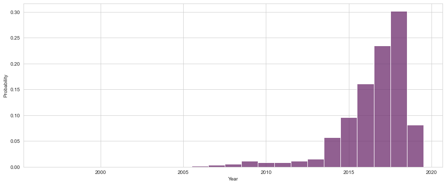

```python
ax = sns.histplot(data=df, x='Year', stat='probability', discrete=True)
ax.figure.set_size_inches(15,6)
```

Esse dataset foi extraido durante o mês de maio de 2019, por isso, é notável essa queda ao fim do gráfico (podemos imaginar que a coluna referente ao ano de 2019 seria maior se os dados tivessem sido extraidos em dezembro). Podemos dar uma olhada na quarta coluna

```python
df['english'].unique()
```

```
array([1, 0], dtype=int64)
```

Aparentemente, só possui 2 valores, indicando se o jogo tem suporte a lingua inglesa ou não. Vale a pena dar uma olhada nos jogos que não possuem esse suporte.

```python
df[df['english'] == 0]
```

|  | appid | name | release_date | english | developer | publisher | platforms | required_age | categories | genres | steamspy_tags | achievements | positive_ratings | negative_ratings | average_playtime | median_playtime | owners | price | Year |
| --- | --- | --- | --- | --- | --- | --- | --- | --- | --- | --- | --- | --- | --- | --- | --- | --- | --- | --- | --- |
| 1297 | 207370 | eXceed - Gun Bullet Children | 2012-08-02 | 0 | Flat Software | Nyu Media | windows | 0 | Single-player;Steam Trading Cards | Action;Indie | Bullet Hell;Anime;Shoot 'Em Up | 0 | 204 | 215 | 97 | 108 | 50000-100000 | 1.99 | 2012 |
| 2221 | 262300 | Tsukumogami | 2012-05-31 | 0 | TORaIKI | Fruitbat Factory | windows | 0 | Single-player | Adventure;Indie;RPG | RPG;Indie;Adventure | 49 | 33 | 17 | 0 | 0 | 50000-100000 | 22.99 | 2012 |
| 3001 | 292990 | NOBUNAGA'S AMBITION: Souzou (Traditional Chine... | 2014-08-01 | 0 | KOEI TECMO GAMES CO., LTD. | KOEI TECMO GAMES CO., LTD. | windows | 0 | Single-player;Steam Cloud | Strategy | Strategy;Historical | 0 | 413 | 74 | 0 | 0 | 20000-50000 | 17.99 | 2014 |
| 3085 | 295950 | 新流星搜劍錄 | 2017-12-20 | 0 | Titans | Titans | windows | 18 | Multi-player;Online Multi-Player;MMO | Violent;Action;Adventure;Indie;Massively Multi... | Action;RPG;Fighting | 0 | 664 | 323 | 0 | 0 | 0-20000 | 15.49 | 2017 |
| 3745 | 318300 | Phineas and Ferb: New Inventions | 2015-02-24 | 0 | PIPE Studio | Disney Interactive | windows | 0 | Single-player | Adventure | Adventure;Psychological Horror;Sexual Content | 0 | 5 | 7 | 0 | 0 | 0-20000 | 15.49 | 2015 |
| ... | ... | ... | ... | ... | ... | ... | ... | ... | ... | ... | ... | ... | ... | ... | ... | ... | ... | ... | ... |
| 27021 | 1056010 | Не падай! | 2019-04-17 | 0 | SharF Co. | SharF Co. | windows | 0 | Single-player;Steam Achievements | Casual;Indie;Racing;Simulation | Casual;Indie;Simulation | 3 | 1 | 1 | 0 | 0 | 0-20000 | 1.69 | 2019 |
| 27024 | 1056500 | VRLife | 2019-04-11 | 0 | Wuhan Mandrill VR Co., Ltd. | Wuhan Mandrill VR Co., Ltd. | windows | 0 | Online Multi-Player;MMO | Casual;Free to Play;Massively Multiplayer;RPG;... | Early Access;Free to Play;Massively Multiplayer | 0 | 16 | 3 | 0 | 0 | 0-20000 | 0.00 | 2019 |
| 27026 | 1056710 | VTB Basketball League VR | 2019-04-12 | 0 | Axyos Games | LikeVR | windows | 0 | Single-player | Casual;Free to Play;Sports | Free to Play;Casual;Sports | 0 | 3 | 0 | 0 | 0 | 0-20000 | 0.00 | 2019 |
| 27036 | 1058000 | Rain's love memory-雨的恋记 | 2019-04-19 | 0 | the original air | the original air | windows | 0 | Single-player | Free to Play | Free to Play;Visual Novel | 0 | 33 | 2 | 0 | 0 | 0-20000 | 0.00 | 2019 |
| 27060 | 1062240 | 地铁：恐怖末班车 | 2019-04-25 | 0 | QZQ Studio | H.P.Y.S,LLC | windows | 0 | Single-player | Action;Adventure;Indie;RPG | Action;Adventure;RPG | 0 | 0 | 2 | 0 | 0 | 0-20000 | 2.09 | 2019 |

511 rows × 19 columns

```python
df[df['english'] == 0].count()
```

```
appid               511
name                511
release_date        511
english             511
developer           511
publisher           511
platforms           511
required_age        511
categories          511
genres              511
steamspy_tags       511
achievements        511
positive_ratings    511
negative_ratings    511
average_playtime    511
median_playtime     511
owners              511
price               511
Year                511
dtype: int64
```

Boa parte deles parece ter vindo de países asiáticos. Interessante. Existe a possibilidade de, devido a esses jogos serem produzidos em países asiáticos, o valor dos mesmos seja menor, uma vez que, na média, o valor das moedas asiaticas é menor que da moeda americana ou européia. Além disso, existe também a possibilidade de a ausência de suporte a lingua inglesa indicar limitações no capital investido na confecção do jogo.  
Podemos dar uma olhada melhor nesse seleto grupo em outro momento, por enquanto, vamos prosseguir.

```python
df['developer'].unique()
```

```
array(['Valve', 'Gearbox Software', 'Valve;Hidden Path Entertainment',
       ..., 'SHEN JIAWEI', 'Semyon Maximov', 'Adept Studios GD'],
      dtype=object)
```

```python
df['developer'].mode()
```

```
0    Choice of Games
dtype: object
```

Essa moda não reflete, de fato, a moda real do conjunto de desenvolvedores, já que vários deles estão concatenados na mesma coluna.

```python
desenv_split = df['developer'].apply(lambda x: pd.Series(x.split(';')))
```

```python
desenv_split
```

|  | 0 | 1 | 2 | 3 | 4 | 5 | 6 | 7 | 8 | 9 | 10 | 11 | 12 | 13 | 14 |
| --- | --- | --- | --- | --- | --- | --- | --- | --- | --- | --- | --- | --- | --- | --- | --- |
| 0 | Valve | NaN | NaN | NaN | NaN | NaN | NaN | NaN | NaN | NaN | NaN | NaN | NaN | NaN | NaN |
| 1 | Valve | NaN | NaN | NaN | NaN | NaN | NaN | NaN | NaN | NaN | NaN | NaN | NaN | NaN | NaN |
| 2 | Valve | NaN | NaN | NaN | NaN | NaN | NaN | NaN | NaN | NaN | NaN | NaN | NaN | NaN | NaN |
| 3 | Valve | NaN | NaN | NaN | NaN | NaN | NaN | NaN | NaN | NaN | NaN | NaN | NaN | NaN | NaN |
| 4 | Gearbox Software | NaN | NaN | NaN | NaN | NaN | NaN | NaN | NaN | NaN | NaN | NaN | NaN | NaN | NaN |
| ... | ... | ... | ... | ... | ... | ... | ... | ... | ... | ... | ... | ... | ... | ... | ... |
| 27070 | SHEN JIAWEI | NaN | NaN | NaN | NaN | NaN | NaN | NaN | NaN | NaN | NaN | NaN | NaN | NaN | NaN |
| 27071 | Semyon Maximov | NaN | NaN | NaN | NaN | NaN | NaN | NaN | NaN | NaN | NaN | NaN | NaN | NaN | NaN |
| 27072 | EntwicklerX | NaN | NaN | NaN | NaN | NaN | NaN | NaN | NaN | NaN | NaN | NaN | NaN | NaN | NaN |
| 27073 | Yustas Game Studio | NaN | NaN | NaN | NaN | NaN | NaN | NaN | NaN | NaN | NaN | NaN | NaN | NaN | NaN |
| 27074 | Adept Studios GD | NaN | NaN | NaN | NaN | NaN | NaN | NaN | NaN | NaN | NaN | NaN | NaN | NaN | NaN |

27075 rows × 15 columns

```python
desenv = []
for index, row in desenv_split.iterrows():
    for i in desenv_split.columns:
        desenv.append(row[i])
```

(Essa foi a solução que eu achei para listar todas as desenvolvedoras. Não foi das mais elegantes, então, se você tiver alguma ideia pra substituir essa monstruosidade, eu estou aberto a sugestões)

```python
desenv = pd.Series(desenv)
```

```python
desenv.dropna(inplace=True)
```

```python
desenv.mode()
```

```
0    Choice of Games
dtype: object
```

Agora temos a verdadeira moda (que, ironicamente, era a mesma de antes).  
Infelizmente, esses dados são muito variados, então, acho improvável transforma-los em variáveis binárias ou ordinais. Dessa forma, existe um maior proveito em simplesmente tentar identificar algumas desenvolvedoras mais proeminentes.

```python
desenv.value_counts().head(10)
```

```
Choice of Games               94
KOEI TECMO GAMES CO., LTD.    75
Ripknot Systems               62
Laush Dmitriy Sergeevich      51
Nikita "Ghost_RUS"            51
Dexion Games                  45
Feral Interactive (Mac)       44
RewindApp                     44
Hosted Games                  42
Blender Games                 40
dtype: int64
```

```python
desenv.value_counts().tail(10)
```

```
Giant Box Games        1
Nuclear Tales          1
Frost Dog Studio       1
Chicken in The Corn    1
Lee Fuller             1
MegawattsCo            1
Rockstar Leeds         1
Redro Games            1
Andy Campbell          1
Toothless T-Rex        1
dtype: int64
```

Provavelmente teremos o mesmo problema com a publisher.

```python
df['publisher'].unique()
```

```
array(['Valve', 'Mark Healey', 'Tripwire Interactive', ..., 'MonteCube',
       'Velvet Paradise Games', 'SHEN JIAWEI'], dtype=object)
```

```python
df['publisher'].mode()
```

```
0    Big Fish Games
dtype: object
```

```python
publi_split = df['publisher'].apply(lambda x: pd.Series(x.split(';')))
```

```python
publi_split
```

|  | 0 | 1 | 2 | 3 | 4 |
| --- | --- | --- | --- | --- | --- |
| 0 | Valve | NaN | NaN | NaN | NaN |
| 1 | Valve | NaN | NaN | NaN | NaN |
| 2 | Valve | NaN | NaN | NaN | NaN |
| 3 | Valve | NaN | NaN | NaN | NaN |
| 4 | Valve | NaN | NaN | NaN | NaN |
| ... | ... | ... | ... | ... | ... |
| 27070 | SHEN JIAWEI | NaN | NaN | NaN | NaN |
| 27071 | BekkerDev Studio | NaN | NaN | NaN | NaN |
| 27072 | EntwicklerX | NaN | NaN | NaN | NaN |
| 27073 | Alawar Entertainment | NaN | NaN | NaN | NaN |
| 27074 | Alawar Entertainment | NaN | NaN | NaN | NaN |

27075 rows × 5 columns

```python
publi = []
for index, row in publi_split.iterrows():
    for i in publi_split.columns:
        publi.append(row[i])
```

```python
publi = pd.Series(publi)
```

```python
publi.dropna(inplace=True)
```

```python
publi.mode()
```

```
0    Big Fish Games
dtype: object
```

```python
publi.value_counts().head(10)
```

```
Big Fish Games       212
Strategy First       136
THQ Nordic           119
Ubisoft              114
Plug In Digital      111
Square Enix          107
Nightdive Studios    101
1C Entertainment      96
Sekai Project         96
Choice of Games       94
dtype: int64
```

```python
publi.value_counts().tail(10)
```

```
Anatola Howard        1
Team Frizz            1
Pixel Wonder          1
Wispfire              1
Arif Games            1
Sergey Sevostyanov    1
Bullet Bears          1
FYRG                  1
Frogmouth             1
Mindwedge             1
dtype: int64
```

Algumas dessas informações são bem interessantes. Particularmente, eu não conhecia algumas dessas empresas.

Agora, seguiremos para avaliar as plataformas

```python
df['platforms'].unique()
```

```
array(['windows;mac;linux', 'windows;mac', 'windows', 'windows;linux',
       'mac', 'mac;linux', 'linux'], dtype=object)
```

Meu palpite é de que, jogos que estão disponíveis em mais plataformas provavelmente venderiam mais, o que pode acarretar no número maior de owners.  
Pensando em como tratar esse campo, talvez seja interessante criar 3 novas colunas de valor binário, pra determinar se um dado jogo está disponível para essa plataforma ou não.

```python
df['platforms_windows'] = df['platforms'].str.contains('windows', regex=False).astype(int)
df['platforms_mac'] = df['platforms'].str.contains('mac', regex=False).astype(int)
df['platforms_linux'] = df['platforms'].str.contains('linux', regex=False).astype(int)
```

```python
df.tail(10)
```

|  | appid | name | release_date | english | developer | publisher | platforms | required_age | categories | genres | ... | positive_ratings | negative_ratings | average_playtime | median_playtime | owners | price | Year | platforms_windows | platforms_mac | platforms_linux |
| --- | --- | --- | --- | --- | --- | --- | --- | --- | --- | --- | --- | --- | --- | --- | --- | --- | --- | --- | --- | --- | --- |
| 27065 | 1063560 | 12 HOURS | 2019-04-24 | 1 | Second Reality | Second Reality | windows | 0 | Single-player | Action;Indie;Simulation;Early Access | ... | 9 | 1 | 0 | 0 | 0-20000 | 2.09 | 2019 | 1 | 0 | 0 |
| 27066 | 1064060 | The Mystery of Bikini Island | 2019-04-24 | 1 | Velvet Paradise Games | Velvet Paradise Games | windows | 0 | Single-player | Adventure;Casual;Indie;RPG;Early Access | ... | 3 | 0 | 0 | 0 | 0-20000 | 0.79 | 2019 | 1 | 0 | 0 |
| 27067 | 1064580 | CaptainMarlene | 2019-04-23 | 1 | Dnovel | Dnovel | windows | 0 | Single-player | Adventure;Indie;Early Access | ... | 13 | 0 | 0 | 0 | 0-20000 | 9.29 | 2019 | 1 | 0 | 0 |
| 27068 | 1064890 | Old Edge II | 2019-04-23 | 1 | LTrust | LTrust | windows | 0 | Single-player | Adventure;Casual;Indie;Simulation | ... | 4 | 0 | 0 | 0 | 0-20000 | 0.79 | 2019 | 1 | 0 | 0 |
| 27069 | 1065160 | Deatherem | 2019-04-23 | 1 | Anima | Team Syukino | windows | 0 | Single-player;Steam Achievements | Indie | ... | 2 | 2 | 0 | 0 | 0-20000 | 2.09 | 2019 | 1 | 0 | 0 |
| 27070 | 1065230 | Room of Pandora | 2019-04-24 | 1 | SHEN JIAWEI | SHEN JIAWEI | windows | 0 | Single-player;Steam Achievements | Adventure;Casual;Indie | ... | 3 | 0 | 0 | 0 | 0-20000 | 2.09 | 2019 | 1 | 0 | 0 |
| 27071 | 1065570 | Cyber Gun | 2019-04-23 | 1 | Semyon Maximov | BekkerDev Studio | windows | 0 | Single-player | Action;Adventure;Indie | ... | 8 | 1 | 0 | 0 | 0-20000 | 1.69 | 2019 | 1 | 0 | 0 |
| 27072 | 1065650 | Super Star Blast | 2019-04-24 | 1 | EntwicklerX | EntwicklerX | windows | 0 | Single-player;Multi-player;Co-op;Shared/Split ... | Action;Casual;Indie | ... | 0 | 1 | 0 | 0 | 0-20000 | 3.99 | 2019 | 1 | 0 | 0 |
| 27073 | 1066700 | New Yankee 7: Deer Hunters | 2019-04-17 | 1 | Yustas Game Studio | Alawar Entertainment | windows;mac | 0 | Single-player;Steam Cloud | Adventure;Casual;Indie | ... | 2 | 0 | 0 | 0 | 0-20000 | 5.19 | 2019 | 1 | 1 | 0 |
| 27074 | 1069460 | Rune Lord | 2019-04-24 | 1 | Adept Studios GD | Alawar Entertainment | windows;mac | 0 | Single-player;Steam Cloud | Adventure;Casual;Indie | ... | 4 | 0 | 0 | 0 | 0-20000 | 5.19 | 2019 | 1 | 1 | 0 |

10 rows × 22 columns

Essa transformação nos permite, também, ter uma noção de quanto jogos estão disponíveis em cada plataforma, simplesmente efetuando uma soma.

```python
df['platforms_windows'].sum()
```

```
27070
```

```python
df['platforms_mac'].sum()
```

```
8066
```

```python
df['platforms_linux'].sum()
```

```
5235
```

Aparentemente, existem mais jogos disponíveis para windows, e, por último, para linux. Acho que é interessante calcular a correlação entre essas 3 variáveis, pra evitar problemas de multicolinearidade futuros.

```python
df[['platforms_windows','platforms_mac','platforms_linux']].corr()
```

|  | platforms_windows | platforms_mac | platforms_linux |
| --- | --- | --- | --- |
| platforms_windows | 1.000000 | -0.014920 | -0.007111 |
| platforms_mac | -0.014920 | 1.000000 | 0.626648 |
| platforms_linux | -0.007111 | 0.626648 | 1.000000 |

Existe uma correlação razoável entre mac e linux. Minha hipótese é a de que, uma vez que windows possui mais entradas, provavelmente quando uma desenvolvedora decide produzir para alguma plataforma, ela opta pelo windows, e, quando quer desenvolver para mais de uma, acaba por optar por desenvolver para linux E mac, e não linux OU mac. Podemos dar uma olhada novamente na coluna platforms, pra ter uma ideia melhor.

```python
df[df['platforms'] == 'windows;mac;linux'].shape[0]
```

```
4623
```

```python
df[df['platforms'] == 'mac;linux'].shape[0]
```

```
1
```

```python
df[df['platforms'] == 'windows;mac'].shape[0]
```

```
3439
```

```python
df[df['platforms'] == 'windows;linux'].shape[0]
```

```
610
```

Como eu pensei. Apesar de poucos jogos serem lançados somente para mac e linux (1), boa parte deles é lançado juntamente com windows. Isso significa que, uma vez que o jogo saia para linux, é esperado também que saia para mac, e o inverso é, em menor grau, também verdade.  
Agora, vamos ver a variável 'required_age'

```python
df['required_age'].unique()
```

```
array([ 0, 18, 16, 12,  7,  3], dtype=int64)
```

O campo 'required_age' está em formato numérico, o que pode facilitar a nossa eventual regressão.

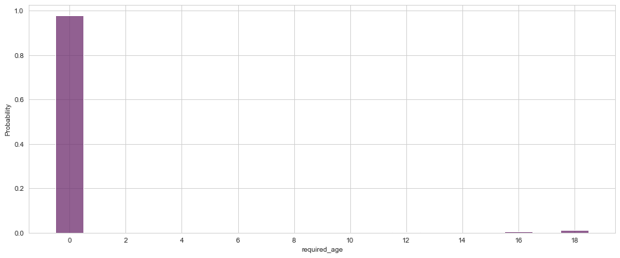

```python
ax = sns.histplot(data=df, x='required_age', discrete=True, stat='probability')
ax.figure.set_size_inches(15,6)
ax.set(xticks=range(0,20,2))
```

Parace que a grande maioria dos jogos na nossa amostra não requer idade mínima. Pode ser interessante, mais pra frente, dar uma olhada na quantidade de pessoas que detem jogos nas últimas duas faixas de idade, por curiosidade.  
Agora, vamos prosseguir para a próxima variável.

```python
df['categories'].unique()
```

```
array(['Multi-player;Online Multi-Player;Local Multi-Player;Valve Anti-Cheat enabled',
       'Multi-player;Valve Anti-Cheat enabled',
       'Single-player;Multi-player;Valve Anti-Cheat enabled', ...,
       'Online Multi-Player;Steam Achievements;Full controller support;In-App Purchases;Steam Cloud',
       'Multi-player;Local Multi-Player;Co-op;Local Co-op;Shared/Split Screen',
       'Multi-player;Online Multi-Player;Cross-Platform Multiplayer;Stats'],
      dtype=object)
```

```python
len(df['categories'].unique().tolist())
```

```
3333
```

Parece que existe uma grande quantidade de variações de categorias. Vou tentar utilizar a mesma técnica que utilizamos para separar developers e publishers, e, dependendo de como ficar, talvez seja viável transforma-las em variáveis binárias, como no caso das platforms.

```python
categ_split = df['categories'].apply(lambda x: pd.Series(x.split(';')))
```

```python
categ_split
```

|  | 0 | 1 | 2 | 3 | 4 | 5 | 6 | 7 | 8 | 9 | 10 | 11 | 12 | 13 | 14 | 15 | 16 | 17 |
| --- | --- | --- | --- | --- | --- | --- | --- | --- | --- | --- | --- | --- | --- | --- | --- | --- | --- | --- |
| 0 | Multi-player | Online Multi-Player | Local Multi-Player | Valve Anti-Cheat enabled | NaN | NaN | NaN | NaN | NaN | NaN | NaN | NaN | NaN | NaN | NaN | NaN | NaN | NaN |
| 1 | Multi-player | Online Multi-Player | Local Multi-Player | Valve Anti-Cheat enabled | NaN | NaN | NaN | NaN | NaN | NaN | NaN | NaN | NaN | NaN | NaN | NaN | NaN | NaN |
| 2 | Multi-player | Valve Anti-Cheat enabled | NaN | NaN | NaN | NaN | NaN | NaN | NaN | NaN | NaN | NaN | NaN | NaN | NaN | NaN | NaN | NaN |
| 3 | Multi-player | Online Multi-Player | Local Multi-Player | Valve Anti-Cheat enabled | NaN | NaN | NaN | NaN | NaN | NaN | NaN | NaN | NaN | NaN | NaN | NaN | NaN | NaN |
| 4 | Single-player | Multi-player | Valve Anti-Cheat enabled | NaN | NaN | NaN | NaN | NaN | NaN | NaN | NaN | NaN | NaN | NaN | NaN | NaN | NaN | NaN |
| ... | ... | ... | ... | ... | ... | ... | ... | ... | ... | ... | ... | ... | ... | ... | ... | ... | ... | ... |
| 27070 | Single-player | Steam Achievements | NaN | NaN | NaN | NaN | NaN | NaN | NaN | NaN | NaN | NaN | NaN | NaN | NaN | NaN | NaN | NaN |
| 27071 | Single-player | NaN | NaN | NaN | NaN | NaN | NaN | NaN | NaN | NaN | NaN | NaN | NaN | NaN | NaN | NaN | NaN | NaN |
| 27072 | Single-player | Multi-player | Co-op | Shared/Split Screen | Steam Achievements | Full controller support | Steam Cloud | NaN | NaN | NaN | NaN | NaN | NaN | NaN | NaN | NaN | NaN | NaN |
| 27073 | Single-player | Steam Cloud | NaN | NaN | NaN | NaN | NaN | NaN | NaN | NaN | NaN | NaN | NaN | NaN | NaN | NaN | NaN | NaN |
| 27074 | Single-player | Steam Cloud | NaN | NaN | NaN | NaN | NaN | NaN | NaN | NaN | NaN | NaN | NaN | NaN | NaN | NaN | NaN | NaN |

27075 rows × 18 columns

Parece que um mesmo jogo pode ter até 18 categorias diferentes. Apesar de serem muitas, eu acredito que isso possa influenciar tanto a quantidade de pessoas que detem o jogo, como o seu preço. Acho que vou ter que criar colunas binárias pra eles então...

```python
categ = []
for index, row in categ_split.iterrows():
    for i in categ_split.columns:
        categ.append(row[i])
```

```python
categ = pd.Series(categ)
```

```python
categ.dropna(inplace=True)
```

```python
categ.unique()
```

```
array(['Multi-player', 'Online Multi-Player', 'Local Multi-Player',
       'Valve Anti-Cheat enabled', 'Single-player', 'Steam Cloud',
       'Steam Achievements', 'Steam Trading Cards', 'Captions available',
       'Partial Controller Support', 'Includes Source SDK',
       'Cross-Platform Multiplayer', 'Stats', 'Commentary available',
       'Includes level editor', 'Steam Workshop', 'In-App Purchases',
       'Co-op', 'Full controller support', 'Steam Leaderboards',
       'SteamVR Collectibles', 'Online Co-op', 'Shared/Split Screen',
       'Local Co-op', 'MMO', 'VR Support', 'Mods', 'Mods (require HL2)',
       'Steam Turn Notifications'], dtype=object)
```

```python
len(categ.unique())
```

```
29
```

Parece que me precipitei. Essencialmente, existem 29 categorias diferentes, só nesta amostra. Talvez seja sim possível que um jogo tenha mais de 18 categorias então. POrém, é perceptível que algumas dessas categorias parecem um pouco redundantes. Talvez seja interessante calcular correlação entre elas. Também pode ser interessante calcular a quantidade de categorias que cada jogo tem, já que o simples número de categorias pode ser um indicador também.

```python
categ.mode()
```

```
0    Single-player
dtype: object
```

```python
categ.value_counts().head(10)
```

```
Single-player                 25678
Steam Achievements            14130
Steam Trading Cards            7918
Steam Cloud                    7219
Full controller support        5695
Partial Controller Support     4234
Multi-player                   3974
Steam Leaderboards             3439
Online Multi-Player            2487
Shared/Split Screen            2152
dtype: int64
```

```python
categ.value_counts().tail(10)
```

```
In-App Purchases            690
MMO                         421
VR Support                  231
Commentary available        144
Valve Anti-Cheat enabled     94
Steam Turn Notifications     63
SteamVR Collectibles         40
Includes Source SDK          35
Mods                          2
Mods (require HL2)            1
dtype: int64
```

```python
categ.unique().tolist()
```

```
['Multi-player',
 'Online Multi-Player',
 'Local Multi-Player',
 'Valve Anti-Cheat enabled',
 'Single-player',
 'Steam Cloud',
 'Steam Achievements',
 'Steam Trading Cards',
 'Captions available',
 'Partial Controller Support',
 'Includes Source SDK',
 'Cross-Platform Multiplayer',
 'Stats',
 'Commentary available',
 'Includes level editor',
 'Steam Workshop',
 'In-App Purchases',
 'Co-op',
 'Full controller support',
 'Steam Leaderboards',
 'SteamVR Collectibles',
 'Online Co-op',
 'Shared/Split Screen',
 'Local Co-op',
 'MMO',
 'VR Support',
 'Mods',
 'Mods (require HL2)',
 'Steam Turn Notifications']
```

```python
df_corr = pd.DataFrame()
df_corr
```

```python
for i in categ.unique().tolist():
    nome = 'categories_'+i
    df[nome] = df['categories'].str.contains(i, regex=False).astype(int)
    df_corr[nome] = df['categories'].str.contains(i, regex=False).astype(int)
```

```python
df_corr.columns
```

```
Index(['categories_Multi-player', 'categories_Online Multi-Player',
       'categories_Local Multi-Player', 'categories_Valve Anti-Cheat enabled',
       'categories_Single-player', 'categories_Steam Cloud',
       'categories_Steam Achievements', 'categories_Steam Trading Cards',
       'categories_Captions available',
       'categories_Partial Controller Support',
       'categories_Includes Source SDK',
       'categories_Cross-Platform Multiplayer', 'categories_Stats',
       'categories_Commentary available', 'categories_Includes level editor',
       'categories_Steam Workshop', 'categories_In-App Purchases',
       'categories_Co-op', 'categories_Full controller support',
       'categories_Steam Leaderboards', 'categories_SteamVR Collectibles',
       'categories_Online Co-op', 'categories_Shared/Split Screen',
       'categories_Local Co-op', 'categories_MMO', 'categories_VR Support',
       'categories_Mods', 'categories_Mods (require HL2)',
       'categories_Steam Turn Notifications'],
      dtype='object')
```

```python
df['categories_QTD'] = 1+ df['categories'].str.contains(';', regex=False).astype(int)
df_corr['categories_QTD'] = 1+ df['categories'].str.contains(';', regex=False).astype(int)
```

```python
df_corr.head(10)
```

|  | categories_Multi-player | categories_Online Multi-Player | categories_Local Multi-Player | categories_Valve Anti-Cheat enabled | categories_Single-player | categories_Steam Cloud | categories_Steam Achievements | categories_Steam Trading Cards | categories_Captions available | categories_Partial Controller Support | ... | categories_SteamVR Collectibles | categories_Online Co-op | categories_Shared/Split Screen | categories_Local Co-op | categories_MMO | categories_VR Support | categories_Mods | categories_Mods (require HL2) | categories_Steam Turn Notifications | categories_QTD |
| --- | --- | --- | --- | --- | --- | --- | --- | --- | --- | --- | --- | --- | --- | --- | --- | --- | --- | --- | --- | --- | --- |
| 0 | 1 | 1 | 1 | 1 | 0 | 0 | 0 | 0 | 0 | 0 | ... | 0 | 0 | 0 | 0 | 0 | 0 | 0 | 0 | 0 | 2 |
| 1 | 1 | 1 | 1 | 1 | 0 | 0 | 0 | 0 | 0 | 0 | ... | 0 | 0 | 0 | 0 | 0 | 0 | 0 | 0 | 0 | 2 |
| 2 | 1 | 0 | 0 | 1 | 0 | 0 | 0 | 0 | 0 | 0 | ... | 0 | 0 | 0 | 0 | 0 | 0 | 0 | 0 | 0 | 2 |
| 3 | 1 | 1 | 1 | 1 | 0 | 0 | 0 | 0 | 0 | 0 | ... | 0 | 0 | 0 | 0 | 0 | 0 | 0 | 0 | 0 | 2 |
| 4 | 1 | 0 | 0 | 1 | 1 | 0 | 0 | 0 | 0 | 0 | ... | 0 | 0 | 0 | 0 | 0 | 0 | 0 | 0 | 0 | 2 |
| 5 | 1 | 1 | 0 | 1 | 0 | 0 | 0 | 0 | 0 | 0 | ... | 0 | 0 | 0 | 0 | 0 | 0 | 0 | 0 | 0 | 2 |
| 6 | 1 | 1 | 0 | 1 | 1 | 1 | 0 | 0 | 0 | 0 | ... | 0 | 0 | 0 | 0 | 0 | 0 | 0 | 0 | 0 | 2 |
| 7 | 1 | 0 | 0 | 1 | 1 | 0 | 0 | 0 | 0 | 0 | ... | 0 | 0 | 0 | 0 | 0 | 0 | 0 | 0 | 0 | 2 |
| 8 | 0 | 0 | 0 | 0 | 1 | 0 | 0 | 0 | 0 | 0 | ... | 0 | 0 | 0 | 0 | 0 | 0 | 0 | 0 | 0 | 1 |
| 9 | 0 | 0 | 0 | 0 | 1 | 1 | 1 | 1 | 1 | 1 | ... | 0 | 0 | 0 | 0 | 0 | 0 | 0 | 0 | 0 | 2 |

10 rows × 30 columns

```python
df_corr.corr()
```

|  | categories_Multi-player | categories_Online Multi-Player | categories_Local Multi-Player | categories_Valve Anti-Cheat enabled | categories_Single-player | categories_Steam Cloud | categories_Steam Achievements | categories_Steam Trading Cards | categories_Captions available | categories_Partial Controller Support | ... | categories_SteamVR Collectibles | categories_Online Co-op | categories_Shared/Split Screen | categories_Local Co-op | categories_MMO | categories_VR Support | categories_Mods | categories_Mods (require HL2) | categories_Steam Turn Notifications | categories_QTD |
| --- | --- | --- | --- | --- | --- | --- | --- | --- | --- | --- | --- | --- | --- | --- | --- | --- | --- | --- | --- | --- | --- |
| categories_Multi-player | 1.000000 | 0.503722 | 0.321236 | 0.122792 | -0.268433 | 0.024880 | 0.008365 | 0.038045 | -0.022577 | 0.049867 | ... | 0.011220 | 0.327593 | 0.273619 | 0.156427 | 0.173948 | 0.022803 | 0.020723 | 0.014653 | 0.081779 | 0.223955 |
| categories_Online Multi-Player | 0.503722 | 1.000000 | 0.244950 | 0.048625 | -0.364006 | -0.009864 | -0.005357 | 0.000474 | -0.022421 | 0.022914 | ... | 0.031050 | 0.541671 | 0.107472 | 0.088209 | 0.233930 | 0.006648 | 0.012146 | -0.001933 | 0.056302 | 0.156664 |
| categories_Local Multi-Player | 0.321236 | 0.244950 | 1.000000 | 0.003693 | -0.107629 | 0.042106 | 0.037201 | 0.000239 | -0.019380 | 0.057296 | ... | -0.009688 | 0.125707 | 0.576333 | 0.532393 | -0.020309 | -0.008103 | -0.002165 | -0.001531 | 0.062281 | 0.136928 |
| categories_Valve Anti-Cheat enabled | 0.122792 | 0.048625 | 0.003693 | 1.000000 | -0.085582 | 0.029730 | 0.027583 | 0.028312 | 0.017538 | 0.017807 | ... | 0.014078 | 0.026680 | -0.005737 | 0.001047 | 0.038259 | 0.015006 | 0.145617 | 0.102965 | -0.002851 | 0.032608 |
| categories_Single-player | -0.268433 | -0.364006 | -0.107629 | -0.085582 | 1.000000 | 0.079473 | 0.083920 | 0.036539 | 0.021987 | -0.015416 | ... | -0.008416 | -0.157390 | -0.066024 | -0.023562 | -0.340444 | -0.011039 | -0.036849 | -0.026056 | -0.009527 | -0.041680 |
| categories_Steam Cloud | 0.024880 | -0.009864 | 0.042106 | 0.029730 | 0.079473 | 1.000000 | 0.385004 | 0.295040 | 0.112453 | 0.023476 | ... | 0.007252 | 0.015186 | 0.092394 | 0.067056 | -0.062278 | -0.005986 | 0.014255 | 0.010079 | 0.017686 | 0.330935 |
| categories_Steam Achievements | 0.008365 | -0.005357 | 0.037201 | 0.027583 | 0.083920 | 0.385004 | 1.000000 | 0.337887 | 0.091724 | 0.055034 | ... | 0.002165 | 0.018232 | 0.081981 | 0.066869 | -0.049431 | -0.003662 | 0.008227 | 0.005817 | 0.033948 | 0.574558 |
| categories_Steam Trading Cards | 0.038045 | 0.000474 | 0.000239 | 0.028312 | 0.036539 | 0.295040 | 0.337887 | 1.000000 | 0.063114 | 0.037730 | ... | 0.000639 | 0.026572 | 0.068636 | 0.034050 | 0.013703 | 0.007455 | -0.005526 | -0.003907 | 0.031304 | 0.353633 |
| categories_Captions available | -0.022577 | -0.022421 | -0.019380 | 0.017538 | 0.021987 | 0.112453 | 0.091724 | 0.063114 | 1.000000 | 0.002684 | ... | -0.000389 | -0.010028 | -0.018071 | -0.010888 | -0.015225 | 0.014588 | -0.001422 | -0.001005 | 0.001535 | 0.089208 |
| categories_Partial Controller Support | 0.049867 | 0.022914 | 0.057296 | 0.017807 | -0.015416 | 0.023476 | 0.055034 | 0.037730 | 0.002684 | 1.000000 | ... | -0.016561 | 0.026876 | 0.073484 | 0.044791 | -0.005619 | 0.016447 | -0.003701 | -0.002617 | -0.018682 | 0.232807 |
| categories_Includes Source SDK | 0.051886 | 0.031266 | 0.016980 | 0.155159 | -0.056663 | 0.015500 | 0.009742 | -0.009571 | 0.064281 | 0.024131 | ... | -0.001384 | 0.019067 | 0.000829 | 0.003346 | 0.012095 | 0.019015 | 0.238900 | 0.168925 | 0.019597 | 0.017447 |
| categories_Cross-Platform Multiplayer | 0.374398 | 0.370801 | 0.100777 | 0.039278 | -0.151986 | 0.010995 | 0.038840 | 0.058418 | -0.012639 | 0.008286 | ... | 0.021626 | 0.244127 | 0.087233 | 0.035730 | 0.154290 | 0.032361 | 0.020197 | -0.001239 | 0.123273 | 0.112659 |
| categories_Stats | 0.110646 | 0.093364 | 0.056457 | 0.055558 | -0.037524 | 0.147696 | 0.212999 | 0.099639 | 0.044234 | 0.034147 | ... | 0.004638 | 0.063926 | 0.071334 | 0.051399 | -0.004937 | 0.007867 | 0.014568 | -0.001659 | 0.056210 | 0.150478 |
| categories_Commentary available | -0.005935 | -0.009190 | -0.007696 | 0.021583 | 0.003283 | 0.022514 | 0.015095 | 0.031132 | 0.098297 | 0.002071 | ... | -0.002813 | -0.004419 | -0.008346 | -0.009514 | 0.011331 | 0.004259 | -0.000628 | -0.000444 | 0.028087 | 0.040397 |
| categories_Includes level editor | 0.113675 | 0.069886 | 0.040000 | 0.060239 | -0.030067 | 0.090900 | 0.064109 | 0.063499 | 0.037564 | 0.040811 | ... | 0.002353 | 0.072127 | 0.056699 | 0.040200 | -0.001726 | 0.038018 | 0.043090 | 0.030469 | 0.026331 | 0.105190 |
| categories_Steam Workshop | 0.103998 | 0.078313 | 0.025700 | 0.101343 | -0.040783 | 0.129659 | 0.091247 | 0.106010 | 0.020653 | 0.029389 | ... | 0.003626 | 0.084188 | 0.037157 | 0.029715 | -0.006585 | 0.043410 | 0.046432 | 0.032832 | 0.021042 | 0.094462 |
| categories_In-App Purchases | 0.143530 | 0.292627 | -0.010052 | 0.042253 | -0.247277 | -0.042387 | -0.017876 | 0.020718 | -0.007824 | -0.007035 | ... | -0.000118 | 0.153554 | -0.026724 | -0.016911 | 0.314963 | -0.009905 | -0.001390 | -0.000983 | 0.031104 | 0.084908 |
| categories_Co-op | 0.426840 | 0.320879 | 0.323010 | 0.070195 | -0.128345 | 0.066205 | 0.067465 | 0.067324 | -0.003380 | 0.068216 | ... | 0.026591 | 0.622128 | 0.383019 | 0.618491 | 0.149355 | 0.009239 | 0.011772 | 0.018631 | 0.007646 | 0.179916 |
| categories_Full controller support | 0.060719 | 0.004983 | 0.188761 | 0.012677 | 0.024928 | 0.249732 | 0.262679 | 0.203712 | 0.042411 | -0.218466 | ... | -0.008055 | 0.025444 | 0.277864 | 0.206736 | -0.050947 | 0.043760 | -0.004436 | -0.003137 | 0.016455 | 0.283196 |
| categories_Steam Leaderboards | 0.090653 | 0.043821 | 0.058479 | 0.032171 | 0.044847 | 0.219241 | 0.292489 | 0.134663 | -0.002466 | 0.037014 | ... | 0.019982 | 0.033554 | 0.129848 | 0.078662 | -0.034492 | 0.021296 | -0.003279 | -0.002318 | 0.041432 | 0.209940 |
| categories_SteamVR Collectibles | 0.011220 | 0.031050 | -0.009688 | 0.014078 | -0.008416 | 0.007252 | 0.002165 | 0.000639 | -0.000389 | -0.016561 | ... | 1.000000 | 0.041529 | -0.011303 | -0.007761 | 0.002938 | 0.174176 | -0.000331 | -0.000234 | -0.001858 | 0.021250 |
| categories_Online Co-op | 0.327593 | 0.541671 | 0.125707 | 0.026680 | -0.157390 | 0.015186 | 0.018232 | 0.026572 | -0.010028 | 0.026876 | ... | 0.041529 | 1.000000 | 0.062960 | 0.194615 | 0.187380 | 0.012078 | -0.001744 | -0.001233 | 0.009863 | 0.112115 |
| categories_Shared/Split Screen | 0.273619 | 0.107472 | 0.576333 | -0.005737 | -0.066024 | 0.092394 | 0.081981 | 0.068636 | -0.018071 | 0.073484 | ... | -0.011303 | 0.062960 | 1.000000 | 0.508408 | -0.031412 | -0.012412 | -0.002526 | -0.001786 | 0.036821 | 0.162335 |
| categories_Local Co-op | 0.156427 | 0.088209 | 0.532393 | 0.001047 | -0.023562 | 0.067056 | 0.066869 | 0.034050 | -0.010888 | 0.044791 | ... | -0.007761 | 0.194615 | 0.508408 | 1.000000 | -0.019197 | -0.008359 | -0.001734 | -0.001226 | 0.010027 | 0.111010 |
| categories_MMO | 0.173948 | 0.233930 | -0.020309 | 0.038259 | -0.340444 | -0.062278 | -0.049431 | 0.013703 | -0.015225 | -0.005619 | ... | 0.002938 | 0.187380 | -0.031412 | -0.019197 | 1.000000 | 0.007816 | -0.001080 | -0.000764 | 0.012518 | 0.058146 |
| categories_VR Support | 0.022803 | 0.006648 | -0.008103 | 0.015006 | -0.011039 | -0.005986 | -0.003662 | 0.007455 | 0.014588 | 0.016447 | ... | 0.174176 | 0.012078 | -0.012412 | -0.008359 | 0.007816 | 1.000000 | -0.000797 | -0.000564 | 0.003855 | 0.045555 |
| categories_Mods | 0.020723 | 0.012146 | -0.002165 | 0.145617 | -0.036849 | 0.014255 | 0.008227 | -0.005526 | -0.001422 | -0.003701 | ... | -0.000331 | -0.001744 | -0.002526 | -0.001734 | -0.001080 | -0.000797 | 1.000000 | 0.707094 | -0.000415 | 0.004748 |
| categories_Mods (require HL2) | 0.014653 | -0.001933 | -0.001531 | 0.102965 | -0.026056 | 0.010079 | 0.005817 | -0.003907 | -0.001005 | -0.002617 | ... | -0.000234 | -0.001233 | -0.001786 | -0.001226 | -0.000764 | -0.000564 | 0.707094 | 1.000000 | -0.000294 | 0.003357 |
| categories_Steam Turn Notifications | 0.081779 | 0.056302 | 0.062281 | -0.002851 | -0.009527 | 0.017686 | 0.033948 | 0.031304 | 0.001535 | -0.018682 | ... | -0.001858 | 0.009863 | 0.036821 | 0.010027 | 0.012518 | 0.003855 | -0.000415 | -0.000294 | 1.000000 | 0.026680 |
| categories_QTD | 0.223955 | 0.156664 | 0.136928 | 0.032608 | -0.041680 | 0.330935 | 0.574558 | 0.353633 | 0.089208 | 0.232807 | ... | 0.021250 | 0.112115 | 0.162335 | 0.111010 | 0.058146 | 0.045555 | 0.004748 | 0.003357 | 0.026680 | 1.000000 |

30 rows × 30 columns

Convenhamos, essa tabela de correlação ficou muito grande, meio inviável de se avaliar. Por isso, vou construir um heatmap abaixo pra ter uma noção um pouco melhor.

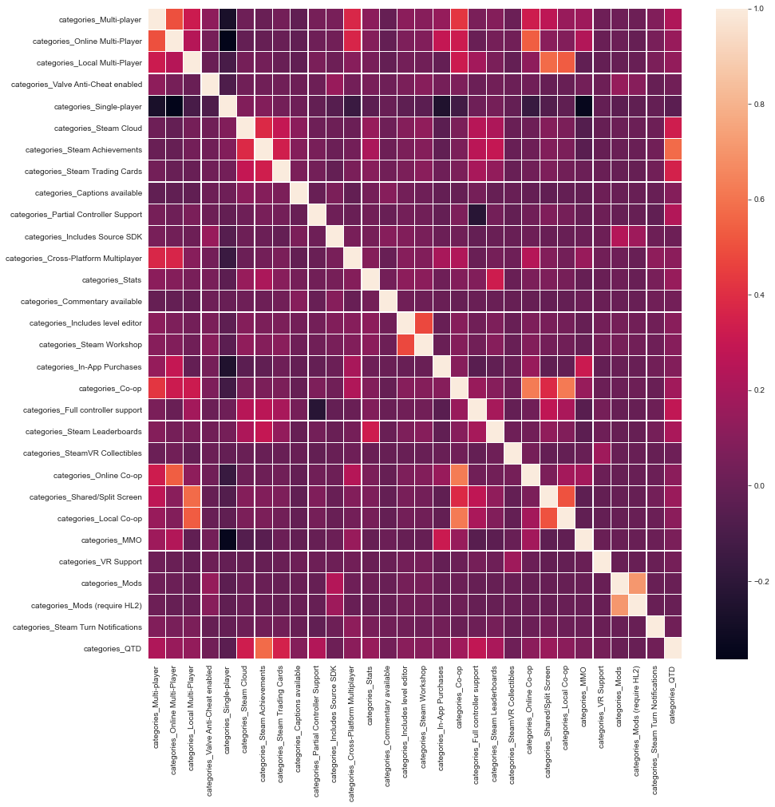

```python
ax = sns.heatmap(df_corr.corr(), linewidths=.2, xticklabels=True, yticklabels=True)
ax.figure.set_size_inches(15,15)
```

Felizmente, a maioria das correlações não foi tão alta, porém, houveram algumas aqui e ali que incomodaram um pouco. Em especial, as colunas:

| Variável A | Variável B |
| --- | --- |
| 'categories_Mods' | 'categories_Mods (require HL2)' |
| 'categories_Shared/Split Screen' | 'categories_Local Co-op' |
| 'categories_Online Co-op' | 'categories_Online Multi-Player' |
| 'categories_Co-op' | 'categories_Local Co-op' |
| 'categories_Co-op' | 'categories_Online Co-op' |

Houveram mais algumas correlações, mas, acredito que com essas que elenquei, já podemos ter uma ideia do que eventualmente jogar fora e o que manter. Já adicionamos as colunas binárias ao dataframe, então, podemos prosseguir para a próxima coluna.

```python
df.columns
```

```
Index(['appid', 'name', 'release_date', 'english', 'developer', 'publisher',
       'platforms', 'required_age', 'categories', 'genres', 'steamspy_tags',
       'achievements', 'positive_ratings', 'negative_ratings',
       'average_playtime', 'median_playtime', 'owners', 'price', 'Year',
       'platforms_windows', 'platforms_mac', 'platforms_linux',
       'categories_Multi-player', 'categories_Online Multi-Player',
       'categories_Local Multi-Player', 'categories_Valve Anti-Cheat enabled',
       'categories_Single-player', 'categories_Steam Cloud',
       'categories_Steam Achievements', 'categories_Steam Trading Cards',
       'categories_Captions available',
       'categories_Partial Controller Support',
       'categories_Includes Source SDK',
       'categories_Cross-Platform Multiplayer', 'categories_Stats',
       'categories_Commentary available', 'categories_Includes level editor',
       'categories_Steam Workshop', 'categories_In-App Purchases',
       'categories_Co-op', 'categories_Full controller support',
       'categories_Steam Leaderboards', 'categories_SteamVR Collectibles',
       'categories_Online Co-op', 'categories_Shared/Split Screen',
       'categories_Local Co-op', 'categories_MMO', 'categories_VR Support',
       'categories_Mods', 'categories_Mods (require HL2)',
       'categories_Steam Turn Notifications', 'categories_QTD'],
      dtype='object')
```

```python
df['genres'].unique()
```

```
array(['Action', 'Action;Free to Play', 'Action;Free to Play;Strategy',
       ...,
       'Action;Adventure;Indie;Massively Multiplayer;RPG;Strategy;Early Access',
       'Action;Adventure;Casual;Free to Play;Indie;RPG;Simulation;Sports;Strategy',
       'Casual;Free to Play;Massively Multiplayer;RPG;Early Access'],
      dtype=object)
```

```python
len(df['genres'].unique())
```

```
1552
```

Parece que teremos que fazer a mesma coisa que fizemos nas últimas variáveis qualitativas.

```python
gen_split = df['genres'].apply(lambda x: pd.Series(x.split(';')))
```

```python
gen_split
```

|  | 0 | 1 | 2 | 3 | 4 | 5 | 6 | 7 | 8 | 9 | 10 | 11 | 12 | 13 | 14 | 15 |
| --- | --- | --- | --- | --- | --- | --- | --- | --- | --- | --- | --- | --- | --- | --- | --- | --- |
| 0 | Action | NaN | NaN | NaN | NaN | NaN | NaN | NaN | NaN | NaN | NaN | NaN | NaN | NaN | NaN | NaN |
| 1 | Action | NaN | NaN | NaN | NaN | NaN | NaN | NaN | NaN | NaN | NaN | NaN | NaN | NaN | NaN | NaN |
| 2 | Action | NaN | NaN | NaN | NaN | NaN | NaN | NaN | NaN | NaN | NaN | NaN | NaN | NaN | NaN | NaN |
| 3 | Action | NaN | NaN | NaN | NaN | NaN | NaN | NaN | NaN | NaN | NaN | NaN | NaN | NaN | NaN | NaN |
| 4 | Action | NaN | NaN | NaN | NaN | NaN | NaN | NaN | NaN | NaN | NaN | NaN | NaN | NaN | NaN | NaN |
| ... | ... | ... | ... | ... | ... | ... | ... | ... | ... | ... | ... | ... | ... | ... | ... | ... |
| 27070 | Adventure | Casual | Indie | NaN | NaN | NaN | NaN | NaN | NaN | NaN | NaN | NaN | NaN | NaN | NaN | NaN |
| 27071 | Action | Adventure | Indie | NaN | NaN | NaN | NaN | NaN | NaN | NaN | NaN | NaN | NaN | NaN | NaN | NaN |
| 27072 | Action | Casual | Indie | NaN | NaN | NaN | NaN | NaN | NaN | NaN | NaN | NaN | NaN | NaN | NaN | NaN |
| 27073 | Adventure | Casual | Indie | NaN | NaN | NaN | NaN | NaN | NaN | NaN | NaN | NaN | NaN | NaN | NaN | NaN |
| 27074 | Adventure | Casual | Indie | NaN | NaN | NaN | NaN | NaN | NaN | NaN | NaN | NaN | NaN | NaN | NaN | NaN |

27075 rows × 16 columns

```python
gen = []
for index, row in gen_split.iterrows():
    for i in gen_split.columns:
        gen.append(row[i])
```

```python
gen = pd.Series(gen)
```

```python
gen.dropna(inplace=True)
```

```python
len(gen.unique())
```

```
29
```

```python
gen.unique()
```

```
array(['Action', 'Free to Play', 'Strategy', 'Adventure', 'Indie', 'RPG',
       'Animation & Modeling', 'Video Production', 'Casual', 'Simulation',
       'Racing', 'Violent', 'Massively Multiplayer', 'Nudity', 'Sports',
       'Early Access', 'Gore', 'Utilities', 'Design & Illustration',
       'Web Publishing', 'Education', 'Software Training',
       'Sexual Content', 'Audio Production', 'Game Development',
       'Photo Editing', 'Accounting', 'Documentary', 'Tutorial'],
      dtype=object)
```

```python
gen.mode()
```

```
0    Indie
dtype: object
```

```python
gen.value_counts().head(10)
```

```
Indie           19421
Action          11903
Casual          10210
Adventure       10032
Strategy         5247
Simulation       5194
RPG              4311
Early Access     2954
Free to Play     1704
Sports           1322
dtype: int64
```

```python
gen.value_counts().tail(10)
```

```
Education            51
Video Production     38
Software Training    31
Audio Production     29
Web Publishing       28
Game Development     17
Photo Editing        12
Accounting            6
Documentary           1
Tutorial              1
dtype: int64
```

Nik Davis, o cara que extraiu essa base, tinha comentado que poderiam haver alguns jogos que não eram realmente jogos, e sim software disponível na steam. Me parece que esses gêneros encontrados com a função tail() podem estar relacionados a esses softwares.

```python
gen.value_counts().tail(50)
```

```
Indie                    19421
Action                   11903
Casual                   10210
Adventure                10032
Strategy                  5247
Simulation                5194
RPG                       4311
Early Access              2954
Free to Play              1704
Sports                    1322
Racing                    1024
Violent                    843
Massively Multiplayer      723
Gore                       537
Nudity                     266
Sexual Content             245
Utilities                  146
Design & Illustration       87
Animation & Modeling        79
Education                   51
Video Production            38
Software Training           31
Audio Production            29
Web Publishing              28
Game Development            17
Photo Editing               12
Accounting                   6
Documentary                  1
Tutorial                     1
dtype: int64
```

```python
gen.value_counts().tail(13).index.tolist()
```

```
['Utilities',
 'Design & Illustration',
 'Animation & Modeling',
 'Education',
 'Video Production',
 'Software Training',
 'Audio Production',
 'Web Publishing',
 'Game Development',
 'Photo Editing',
 'Accounting',
 'Documentary',
 'Tutorial']
```

Esses parecem ser os gêneros a serem verificados. Vou filtrar o dataframe para dar uma olhada nos titulos desses "jogos".

```python
nomes = []
for i in gen.value_counts().tail(13).index.tolist():

    nomes.extend(df[df['genres'].str.contains(i)]['name'].tolist())
```

```python
set(nomes)
```

```
{'001 Game Creator',
 '10k',
 '3D ParticleGen Visual FX',
 '3DCoat 4.8',
 '3DCoat Modding Tool',
 '3DF Zephyr Lite Steam Edition',
 '3DMark 11',
 '8 Queens',
 'ASMR Universe',
 'ASMR Universe 2',
 'Aartform Curvy 3D 3.0',
 'Amaze: Interactive VR Movies',
 'AnimVR',
 'AppGameKit: Easy Game Development',
 'Arcade Artist',
 'Arcane Mapper',
 'Atlantia Animation',
 'AutoTileGen',
 "Axis Game Factory's AGFPRO v3",
 'BASIC8',
 'BeanVR—The Social VR APP',
 'Belle II in Virtual Reality',
 'Blocks by Google',
 'Button Music',
 'Buzz Aldrin: Cycling Pathways to Mars',
 'CINEVR - The Movie Theater',
 'CPUCores :: Maximize Your FPS',
 "Cairo's Tale: The Big Egg",
 'Campfire Pro',
 'Catzilla 4K - Advanced',
 'Chernobyl VR Project',
 'ClearMem :: Free Up Your RAM',
 'Clickteam Fusion 2.5',
 'Club Lighting',
 'ControlMyJoystick',
 'Controller Companion',
 'CopperCube 5 Game Engine',
 'CyberLink PowerDVD 18 Ultra - Media player, video player, 4k media player, 360 video',
 'DJ Mix Pads',
 'DJ Streamer',
```

[output cut: 173 more lines]

```
 'articy:draft 3',
 'articy:draft 3 - Flex License',
 'connect - Virtual Home (3D or VR)',
 'ePic Character Generator',
 'iVRy Driver for SteamVR',
 'liteCam Game 5:  120 FPS Game Capture + Streamer',
 'liteCam Game: 100 FPS Game Capture',
 'liteCam HD 5.0: Screen/Stream Capture',
 'mdiapp+ SE',
 'openCanvas 6',
 'openCanvas 7',
 'rumii',
 'sheepChat',
 'vBuilder',
 '英语杀'}
```

```python
len(set(nomes))
```

```
228
```

Podemos ver que o número não é tão expressivo. E, de fato, varios dos "jogos" são, claramente, softwares de criação de jogos e afins. Vamos ver quais são as categorias ligadas a esses jogos.

```python
df.columns
```

```
Index(['appid', 'name', 'release_date', 'english', 'developer', 'publisher',
       'platforms', 'required_age', 'categories', 'genres', 'steamspy_tags',
       'achievements', 'positive_ratings', 'negative_ratings',
       'average_playtime', 'median_playtime', 'owners', 'price', 'Year',
       'platforms_windows', 'platforms_mac', 'platforms_linux',
       'categories_Multi-player', 'categories_Online Multi-Player',
       'categories_Local Multi-Player', 'categories_Valve Anti-Cheat enabled',
       'categories_Single-player', 'categories_Steam Cloud',
       'categories_Steam Achievements', 'categories_Steam Trading Cards',
       'categories_Captions available',
       'categories_Partial Controller Support',
       'categories_Includes Source SDK',
       'categories_Cross-Platform Multiplayer', 'categories_Stats',
       'categories_Commentary available', 'categories_Includes level editor',
       'categories_Steam Workshop', 'categories_In-App Purchases',
       'categories_Co-op', 'categories_Full controller support',
       'categories_Steam Leaderboards', 'categories_SteamVR Collectibles',
       'categories_Online Co-op', 'categories_Shared/Split Screen',
       'categories_Local Co-op', 'categories_MMO', 'categories_VR Support',
       'categories_Mods', 'categories_Mods (require HL2)',
       'categories_Steam Turn Notifications', 'categories_QTD'],
      dtype='object')
```

```python
df[df['name'].isin(nomes)]['categories'].unique()
```

```
array(['Steam Workshop', 'Steam Cloud', 'Steam Leaderboards',
       'Steam Trading Cards;Steam Workshop',
       'Steam Achievements;Steam Cloud;Stats', 'Single-player',
       'Single-player;Multi-player;MMO;Co-op;Shared/Split Screen;Cross-Platform Multiplayer;Steam Achievements;Steam Leaderboards',
       'Single-player;Steam Achievements;Steam Workshop;In-App Purchases;Partial Controller Support;Includes level editor',
       'Includes level editor',
       'Single-player;Multi-player;Partial Controller Support;Includes level editor',
       'Single-player;Steam Achievements;Steam Leaderboards',
       'Single-player;Multi-player;Includes level editor',
       'Single-player;Steam Achievements', 'Single-player;Steam Cloud',
       'Steam Achievements;Steam Trading Cards;Steam Workshop',
       'Single-player;Steam Trading Cards',
       'Multi-player;Cross-Platform Multiplayer',
       'VR Support;SteamVR Collectibles', 'Steam Trading Cards',
       'Includes Source SDK', 'Steam Achievements',
       'Steam Achievements;Partial Controller Support;Stats;Includes level editor',
       'Steam Achievements;Steam Workshop;Steam Cloud;Stats',
       'Full controller support;Steam Workshop;Steam Leaderboards',
       'Steam Trading Cards;Partial Controller Support',
       'Steam Achievements;Steam Trading Cards;Partial Controller Support;Includes level editor',
       'Full controller support;Steam Workshop',
       'Full controller support;Includes level editor',
       'Partial Controller Support;Includes level editor',
       'Steam Achievements;Steam Trading Cards',
       'VR Support;Steam Workshop', 'Steam Trading Cards;Steam Cloud',
       'VR Support', 'Captions available',
       'Steam Achievements;Steam Cloud',
       'Steam Achievements;Steam Trading Cards;Steam Workshop;Includes level editor',
       'Full controller support;VR Support',
       'VR Support;Partial Controller Support', 'Full controller support',
       'Single-player;Partial Controller Support',
       'Partial Controller Support', 'Single-player;Steam Workshop',
       'Steam Achievements;Steam Trading Cards;Steam Cloud;Stats;Includes level editor',
       'Steam Achievements;Includes level editor', 'Steam Cloud;Stats',
       'Steam Workshop;Partial Controller Support',
       'Single-player;Multi-player;Online Multi-Player',
       'Steam Workshop;Steam Cloud',
       'Partial Controller Support;Steam Cloud',
       'Single-player;Local Multi-Player;Local Co-op',
       'Steam Achievements;Steam Workshop;Steam Cloud',
```

[output cut: 14 more lines]

```
       'Full controller support;In-App Purchases',
       'Steam Cloud;Includes level editor',
       'In-App Purchases;Includes level editor',
       'Single-player;Multi-player;Online Multi-Player;Cross-Platform Multiplayer;Includes level editor',
       'Steam Workshop;Partial Controller Support;Includes level editor',
       'Single-player;Full controller support;In-App Purchases',
       'Steam Workshop;Steam Cloud;Stats',
       'Single-player;Full controller support',
       'Online Multi-Player;Online Co-op;Cross-Platform Multiplayer',
       'Single-player;Captions available',
       'Single-player;Includes level editor',
       'Steam Workshop;Includes Source SDK',
       'Steam Achievements;Steam Workshop', 'In-App Purchases;Stats',
       'Single-player;Steam Cloud;Includes level editor',
       'Steam Workshop;Steam Cloud;Includes level editor'], dtype=object)
```

```python
df[df['name'].isin(nomes)]['categories'].mode()
```

```
0    Single-player
dtype: object
```

```python
df[df['name'].isin(nomes)]['categories'].value_counts().head(10)
```

```
Single-player                 34
Partial Controller Support    19
Steam Workshop                16
Steam Achievements            12
Steam Cloud                   11
Includes level editor         11
Full controller support        8
In-App Purchases               8
Steam Trading Cards            6
VR Support                     6
Name: categories, dtype: int64
```

Considerando tanto as categorias como os gêneros, é possível afirmar com um pouco mais de propriedade que essas entradas são, de fato, em grande maioria, ferramentas de desenvolvimento de jogos. Como o volume também é baixo, vou exclui-las do dataframe.

```python
df = df[~df['name'].isin(nomes)]
```

```python
df.head()
```

|  | appid | name | release_date | english | developer | publisher | platforms | required_age | categories | genres | ... | categories_SteamVR Collectibles | categories_Online Co-op | categories_Shared/Split Screen | categories_Local Co-op | categories_MMO | categories_VR Support | categories_Mods | categories_Mods (require HL2) | categories_Steam Turn Notifications | categories_QTD |
| --- | --- | --- | --- | --- | --- | --- | --- | --- | --- | --- | --- | --- | --- | --- | --- | --- | --- | --- | --- | --- | --- |
| 0 | 10 | Counter-Strike | 2000-11-01 | 1 | Valve | Valve | windows;mac;linux | 0 | Multi-player;Online Multi-Player;Local Multi-P... | Action | ... | 0 | 0 | 0 | 0 | 0 | 0 | 0 | 0 | 0 | 2 |
| 1 | 20 | Team Fortress Classic | 1999-04-01 | 1 | Valve | Valve | windows;mac;linux | 0 | Multi-player;Online Multi-Player;Local Multi-P... | Action | ... | 0 | 0 | 0 | 0 | 0 | 0 | 0 | 0 | 0 | 2 |
| 2 | 30 | Day of Defeat | 2003-05-01 | 1 | Valve | Valve | windows;mac;linux | 0 | Multi-player;Valve Anti-Cheat enabled | Action | ... | 0 | 0 | 0 | 0 | 0 | 0 | 0 | 0 | 0 | 2 |
| 3 | 40 | Deathmatch Classic | 2001-06-01 | 1 | Valve | Valve | windows;mac;linux | 0 | Multi-player;Online Multi-Player;Local Multi-P... | Action | ... | 0 | 0 | 0 | 0 | 0 | 0 | 0 | 0 | 0 | 2 |
| 4 | 50 | Half-Life: Opposing Force | 1999-11-01 | 1 | Gearbox Software | Valve | windows;mac;linux | 0 | Single-player;Multi-player;Valve Anti-Cheat en... | Action | ... | 0 | 0 | 0 | 0 | 0 | 0 | 0 | 0 | 0 | 2 |

5 rows × 52 columns

Agora que limpamos a base de prováveis entradas de software, vale a pena reiniciar o processo de separação dos gêneros. Imagino que, como sobraram menos gêneros, talvez seja possível transforma-los em binário também.

```python
df['genres'].unique()
```

```
array(['Action', 'Action;Free to Play', 'Action;Free to Play;Strategy',
       ...,
       'Action;Adventure;Indie;Massively Multiplayer;RPG;Strategy;Early Access',
       'Action;Adventure;Casual;Free to Play;Indie;RPG;Simulation;Sports;Strategy',
       'Casual;Free to Play;Massively Multiplayer;RPG;Early Access'],
      dtype=object)
```

```python
gen_split = df['genres'].apply(lambda x: pd.Series(x.split(';')))
```

```python
gen_split
```

|  | 0 | 1 | 2 | 3 | 4 | 5 | 6 | 7 | 8 | 9 | 10 |
| --- | --- | --- | --- | --- | --- | --- | --- | --- | --- | --- | --- |
| 0 | Action | NaN | NaN | NaN | NaN | NaN | NaN | NaN | NaN | NaN | NaN |
| 1 | Action | NaN | NaN | NaN | NaN | NaN | NaN | NaN | NaN | NaN | NaN |
| 2 | Action | NaN | NaN | NaN | NaN | NaN | NaN | NaN | NaN | NaN | NaN |
| 3 | Action | NaN | NaN | NaN | NaN | NaN | NaN | NaN | NaN | NaN | NaN |
| 4 | Action | NaN | NaN | NaN | NaN | NaN | NaN | NaN | NaN | NaN | NaN |
| ... | ... | ... | ... | ... | ... | ... | ... | ... | ... | ... | ... |
| 27070 | Adventure | Casual | Indie | NaN | NaN | NaN | NaN | NaN | NaN | NaN | NaN |
| 27071 | Action | Adventure | Indie | NaN | NaN | NaN | NaN | NaN | NaN | NaN | NaN |
| 27072 | Action | Casual | Indie | NaN | NaN | NaN | NaN | NaN | NaN | NaN | NaN |
| 27073 | Adventure | Casual | Indie | NaN | NaN | NaN | NaN | NaN | NaN | NaN | NaN |
| 27074 | Adventure | Casual | Indie | NaN | NaN | NaN | NaN | NaN | NaN | NaN | NaN |

26846 rows × 11 columns

```python
gen = []
for index, row in gen_split.iterrows():
    for i in gen_split.columns:
        gen.append(row[i])
```

```python
gen = pd.Series(gen)
```

```python
gen.dropna(inplace=True)
```

```python
gen.mode()
```

```
0    Indie
dtype: object
```

```python
gen.unique()
```

```
array(['Action', 'Free to Play', 'Strategy', 'Adventure', 'Indie', 'RPG',
       'Casual', 'Simulation', 'Racing', 'Violent',
       'Massively Multiplayer', 'Nudity', 'Sports', 'Early Access',
       'Gore', 'Sexual Content'], dtype=object)
```

```python
len(gen.unique())
```

```
16
```

```python
gen.value_counts().head(10)
```

```
Indie           19399
Action          11901
Casual          10191
Adventure       10028
Strategy         5245
Simulation       5177
RPG              4309
Early Access     2908
Free to Play     1696
Sports           1322
dtype: int64
```

```python
gen.value_counts().tail(10)
```

```
RPG                      4309
Early Access             2908
Free to Play             1696
Sports                   1322
Racing                   1024
Violent                   842
Massively Multiplayer     721
Gore                      536
Nudity                    266
Sexual Content            245
dtype: int64
```

```python
df_corr = pd.DataFrame()
df_corr
```

```python
for i in gen.unique().tolist():
    nome = 'genres_'+i
    df[nome] = df['genres'].str.contains(i, regex=False).astype(int)
    df_corr[nome] = df['genres'].str.contains(i, regex=False).astype(int)
```

```python
df_corr.head(10)
```

|  | genres_Action | genres_Free to Play | genres_Strategy | genres_Adventure | genres_Indie | genres_RPG | genres_Casual | genres_Simulation | genres_Racing | genres_Violent | genres_Massively Multiplayer | genres_Nudity | genres_Sports | genres_Early Access | genres_Gore | genres_Sexual Content |
| --- | --- | --- | --- | --- | --- | --- | --- | --- | --- | --- | --- | --- | --- | --- | --- | --- |
| 0 | 1 | 0 | 0 | 0 | 0 | 0 | 0 | 0 | 0 | 0 | 0 | 0 | 0 | 0 | 0 | 0 |
| 1 | 1 | 0 | 0 | 0 | 0 | 0 | 0 | 0 | 0 | 0 | 0 | 0 | 0 | 0 | 0 | 0 |
| 2 | 1 | 0 | 0 | 0 | 0 | 0 | 0 | 0 | 0 | 0 | 0 | 0 | 0 | 0 | 0 | 0 |
| 3 | 1 | 0 | 0 | 0 | 0 | 0 | 0 | 0 | 0 | 0 | 0 | 0 | 0 | 0 | 0 | 0 |
| 4 | 1 | 0 | 0 | 0 | 0 | 0 | 0 | 0 | 0 | 0 | 0 | 0 | 0 | 0 | 0 | 0 |
| 5 | 1 | 0 | 0 | 0 | 0 | 0 | 0 | 0 | 0 | 0 | 0 | 0 | 0 | 0 | 0 | 0 |
| 6 | 1 | 0 | 0 | 0 | 0 | 0 | 0 | 0 | 0 | 0 | 0 | 0 | 0 | 0 | 0 | 0 |
| 7 | 1 | 0 | 0 | 0 | 0 | 0 | 0 | 0 | 0 | 0 | 0 | 0 | 0 | 0 | 0 | 0 |
| 8 | 1 | 0 | 0 | 0 | 0 | 0 | 0 | 0 | 0 | 0 | 0 | 0 | 0 | 0 | 0 | 0 |
| 9 | 1 | 0 | 0 | 0 | 0 | 0 | 0 | 0 | 0 | 0 | 0 | 0 | 0 | 0 | 0 | 0 |

```python
df_corr.corr()
```

|  | genres_Action | genres_Free to Play | genres_Strategy | genres_Adventure | genres_Indie | genres_RPG | genres_Casual | genres_Simulation | genres_Racing | genres_Violent | genres_Massively Multiplayer | genres_Nudity | genres_Sports | genres_Early Access | genres_Gore | genres_Sexual Content |
| --- | --- | --- | --- | --- | --- | --- | --- | --- | --- | --- | --- | --- | --- | --- | --- | --- |
| genres_Action | 1.000000 | -0.025227 | -0.156237 | 0.012327 | 0.097356 | -0.029661 | -0.173166 | -0.140261 | 0.022335 | 0.099691 | 0.053049 | -0.023407 | -0.010067 | 0.102506 | 0.077398 | -0.040695 |
| genres_Free to Play | -0.025227 | 1.000000 | 0.030372 | -0.043528 | -0.051140 | 0.044122 | 0.003528 | 0.003859 | -0.007747 | -0.012468 | 0.286455 | -0.004336 | 0.005295 | 0.026745 | -0.012984 | 0.008891 |
| genres_Strategy | -0.156237 | 0.030372 | 1.000000 | -0.142592 | -0.025821 | 0.079887 | -0.015110 | 0.144437 | -0.064775 | -0.029917 | 0.044826 | -0.030324 | -0.020096 | 0.043788 | -0.031379 | -0.028519 |
| genres_Adventure | 0.012327 | -0.043528 | -0.142592 | 1.000000 | 0.064279 | 0.167907 | -0.039149 | -0.100087 | -0.075781 | 0.039973 | -0.008250 | 0.024597 | -0.115238 | -0.019387 | 0.049975 | 0.012538 |
| genres_Indie | 0.097356 | -0.051140 | -0.025821 | 0.064279 | 1.000000 | 0.022734 | 0.103029 | -0.043002 | -0.032554 | 0.005045 | -0.066387 | -0.001858 | -0.039328 | 0.075940 | 0.027172 | 0.004342 |
| genres_RPG | -0.029661 | 0.044122 | 0.079887 | 0.167907 | 0.022734 | 1.000000 | -0.135654 | -0.034968 | -0.058467 | 0.003407 | 0.119434 | 0.019778 | -0.068092 | 0.064402 | 0.002153 | 0.010325 |
| genres_Casual | -0.173166 | 0.003528 | -0.015110 | -0.039149 | 0.103029 | -0.135654 | 1.000000 | 0.057542 | -0.012311 | -0.062811 | -0.040214 | 0.024817 | 0.026661 | -0.068142 | -0.057875 | 0.030669 |
| genres_Simulation | -0.140261 | 0.003859 | 0.144437 | -0.100087 | -0.043002 | -0.034968 | 0.057542 | 1.000000 | 0.085044 | -0.018619 | 0.029179 | 0.005438 | 0.187221 | 0.090294 | -0.023868 | 0.010677 |
| genres_Racing | 0.022335 | -0.007747 | -0.064775 | -0.075781 | -0.032554 | -0.058467 | -0.012311 | 0.085044 | 1.000000 | -0.014635 | 0.024658 | -0.015994 | 0.267448 | 0.025705 | -0.011741 | -0.015021 |
| genres_Violent | 0.099691 | -0.012468 | -0.029917 | 0.039973 | 0.005045 | 0.003407 | -0.062811 | -0.018619 | -0.014635 | 1.000000 | 0.005799 | 0.193451 | -0.020211 | 0.033552 | 0.655706 | 0.153530 |
| genres_Massively Multiplayer | 0.053049 | 0.286455 | 0.044826 | -0.008250 | -0.066387 | 0.119434 | -0.040214 | 0.029179 | 0.024658 | 0.005799 | 1.000000 | -0.009640 | 0.014371 | 0.100754 | -0.002298 | -0.013520 |
| genres_Nudity | -0.023407 | -0.004336 | -0.030324 | 0.024597 | -0.001858 | 0.019778 | 0.024817 | 0.005438 | -0.015994 | 0.193451 | -0.009640 | 1.000000 | -0.021029 | -0.010665 | 0.157789 | 0.599445 |
| genres_Sports | -0.010067 | 0.005295 | -0.020096 | -0.115238 | -0.039328 | -0.068092 | 0.026661 | 0.187221 | 0.267448 | -0.020211 | 0.014371 | -0.021029 | 1.000000 | 0.044756 | -0.020177 | -0.018220 |
| genres_Early Access | 0.102506 | 0.026745 | 0.043788 | -0.019387 | 0.075940 | 0.064402 | -0.068142 | 0.090294 | 0.025705 | 0.033552 | 0.100754 | -0.010665 | 0.044756 | 1.000000 | 0.024796 | -0.022106 |
| genres_Gore | 0.077398 | -0.012984 | -0.031379 | 0.049975 | 0.027172 | 0.002153 | -0.057875 | -0.023868 | -0.011741 | 0.655706 | -0.002298 | 0.157789 | -0.020177 | 0.024796 | 1.000000 | 0.106715 |
| genres_Sexual Content | -0.040695 | 0.008891 | -0.028519 | 0.012538 | 0.004342 | 0.010325 | 0.030669 | 0.010677 | -0.015021 | 0.153530 | -0.013520 | 0.599445 | -0.018220 | -0.022106 | 0.106715 | 1.000000 |

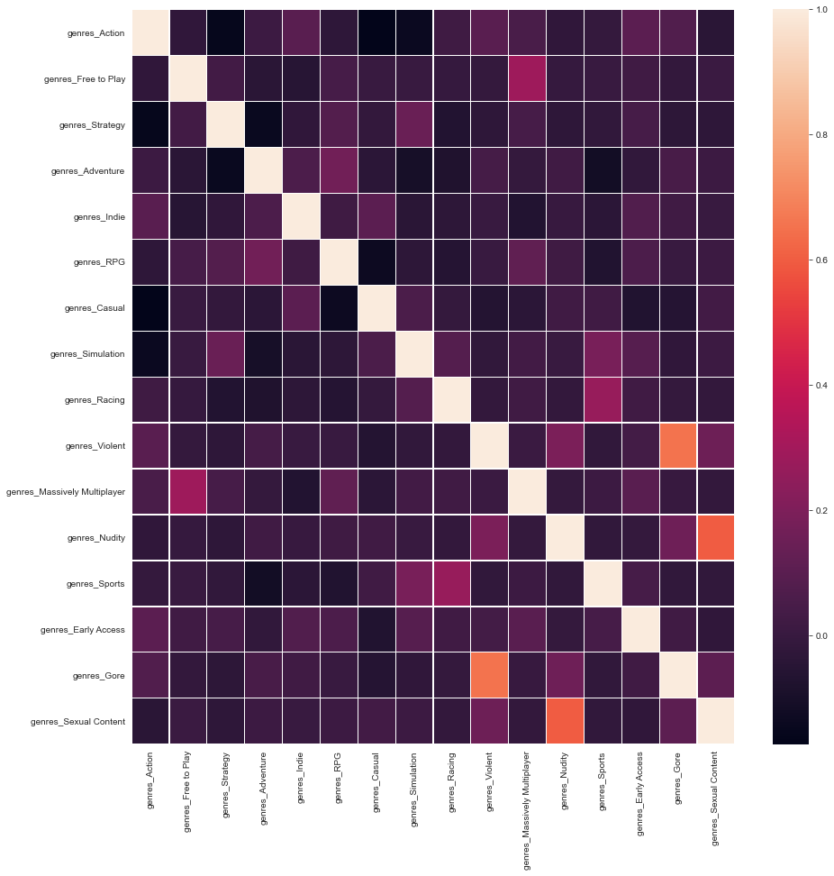

```python
ax = sns.heatmap(df_corr.corr(), linewidths=.2, xticklabels=True, yticklabels=True)
ax.figure.set_size_inches(15,15)
```

Nesse caso, houveram apenas 2 "grandes" correlações.

| Variável A | Variável B |
| --- | --- |
| genres_Nudity | genres_Sexual Content |
| genres_Violent | genres_Gore |

Provavelmente teremos que escolher 1 variável de cada linha para utilizar na eventual regressão. Vamos para a próxima variável

```python
df['achievements'].unique()
```

```
array([   0,   33,  147,   54,   13,   15,   22,  520,   73,   70,   51,
         66,  167,   44,  285,   12,   69,   21,   14,   37,   29,   67,
         61,   50,   80,  286,   60,   11,  709,   20,   38,   30,   40,
         10,   17,   25,   52,   71,   57,    7,   36,    9,   16,    4,
        106,  247,   58,    8,   87,   45,   27,   18,   92,   19,   43,
         75, 1165,  169,   56,   23,  260,   28,   59,   24,   26,   47,
        140,   97,  145,   49,  322,   64,   35,   62,   81,   41,   68,
         88,    1,   63,   48,   83,  129,  110,  114,   90,   77,   65,
         32,   42,  100,   46,  115,  124,  220,  251,  104,   99,  650,
         34,   31,   53,   85,  119,   98,  161,   74,  412,   91,   93,
        113,  849,  111,    2,  150,  213,   82,  107,  188,  146,   95,
       1130,  178,  103,  294,    6,  123,   89,   39,  210,  109,  141,
        187,  452,  257,  134,  108,  295,  300,  120,    3,  183,  105,
        490,   72,  199,  237,  403,  121,  159,   86, 1448,  175,   76,
       1746,  125,  131,   55,  152,    5,  127,  130,  236,   78,  256,
```

[output cut: 23 more lines]

Pelo que pode ser visto, esse campo já está em formato numérico, o que facilita muita coisa. Podemos dar uma olhada no seu histograma, apenas pra ter uma noção melhor da distribuição dos dados.

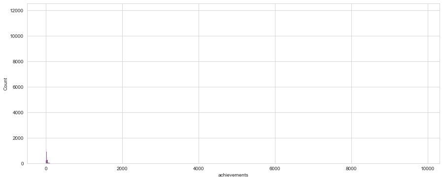

```python
ax = sns.histplot(data=df['achievements'])
ax.figure.set_size_inches(15,6)
```

Parece que o histograma não foi muito útil como forma de visualização desses dados. Vamos tentar o boxplot.

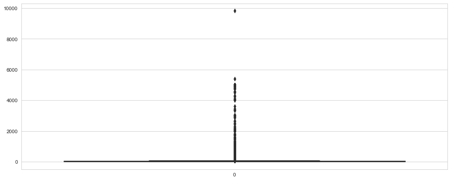

```python
ax = sns.boxplot(data=df['achievements'])
ax.figure.set_size_inches(15,6)
```

```python
df['achievements'].mean()
```

```
45.613536467257696
```

```python
df['achievements'].std()
```

```
354.1483340105123
```

```python
df['achievements'].var()
```

```
125421.04248242141
```

```python
df['achievements'].max()
```

```
9821
```

```python
df['achievements'].min()
```

```
0
```

```python
df['achievements']
```

```
0         0
1         0
2         0
3         0
4         0
         ..
27070     7
27071     0
27072    24
27073     0
27074     0
Name: achievements, Length: 26846, dtype: int64
```

```python
df['achievements'].dropna()
```

```
0         0
1         0
2         0
3         0
4         0
         ..
27070     7
27071     0
27072    24
27073     0
27074     0
Name: achievements, Length: 26846, dtype: int64
```

Bom, parece que esse campo é um pouco estranho mesmo. O desvio padrão é bem alto, o que indica que poucos valores de achievements se repetem entre os jogos, e que eles não estão exatamente próximos um dos outros.  
Vamos pra próxima variável.

```python
df['positive_ratings'].unique()
```

```
array([124534,   3318,   3416, ...,   1720,   2966,   1490], dtype=int64)
```

```python
len(df['positive_ratings'].unique())
```

```
2791
```

```python
df['positive_ratings'].max()
```

```
2644404
```

```python
df['positive_ratings'].min()
```

```
0
```

```python
df['positive_ratings'].mean()
```

```
1004.7550845563585
```

```python
df['positive_ratings'].std()
```

```
19065.287190135652
```

```python
df['positive_ratings'].var()
```

```
363485175.64235055
```

Tentei plotar os gráficos de histograma e boxplot, mas, não deu muito certo, muito tempo de processamento, preferi retirar da análise.

Esse campo diz qual a quantidade de análises positivas que um dado jogo tem. Ele tem um par, que é o campo 'negative_ratings'. Podemos verificar se existe alguma correlação forte entre eles.

```python
df['negative_ratings'].unique()
```

```
array([3339,  633,  398, ..., 1780, 1332, 1035], dtype=int64)
```

```python
len(df['negative_ratings'].unique())
```

```
1488
```

```python
df['negative_ratings'].max()
```

```
487076
```

```python
df['negative_ratings'].min()
```

```
0
```

```python
df['negative_ratings'].mean()
```

```
212.34172688668704
```

```python
df['negative_ratings'].std()
```

```
4303.099997223416
```

```python
df['negative_ratings'].var()
```

```
18516669.58610416
```

Vamos a correlação

```python
df[['negative_ratings','positive_ratings']].corr()
```

|  | negative_ratings | positive_ratings |
| --- | --- | --- |
| negative_ratings | 1.000000 | 0.762909 |
| positive_ratings | 0.762909 | 1.000000 |

Como já era de se esperar, a correlação entre as avaliações realmente é consideravel, porém, é interessante notar que elas tem uma correlação positiva. Isso pode indicar que elas são, na verdade, proporcionais a quantidade de avaliações. Como elas tem uma correlação bem alta, vou criar uma terceira variável, que será a subtração dessas duas, e vou usar ela na eventual regressão.

```python
df['delta_ratings'] = df['positive_ratings'] - df['negative_ratings']
```

```python
df['delta_ratings'].unique()
```

```
array([121195,   2685,   3018, ...,    472,    600,    611], dtype=int64)
```

```python
len(df['delta_ratings'].unique())
```

```
2712
```

```python
df['delta_ratings'].max()
```

```
2242091
```

```python
df['delta_ratings'].min()
```

```
-7738
```

```python
df['delta_ratings'].mean()
```

```
792.4133576696714
```

```python
df['delta_ratings'].std()
```

```
16025.730333753105
```

```python
df['delta_ratings'].var()
```

```
256824032.73017442
```

Vou calcular também uma nota média baseada no percentual de votos positivos.

```python
df['%_ratings'] = df['positive_ratings']/(df['positive_ratings'] + df['negative_ratings'])
```

```python
df['%_ratings'].unique()
```

```
array([0.97388815, 0.8397874 , 0.89564761, ..., 0.64197531, 0.68209877,
       0.77692308])
```

```python
len(df['%_ratings'].unique())
```

```
8402
```

```python
df['%_ratings'].max()
```

```
1.0
```

```python
df['%_ratings'].min()
```

```
0.0
```

```python
df['%_ratings'].mean()
```

```
0.7144242187237336
```

Parece que encontramos um outro ponto de atenção. É bem provável que essas entradas com nota percentual 1 e 0 sejam, na verdade, casos com poucas avaliações. Será que o número de avaliações pode ter influência no seu preço? Na quantidade, eu imagino que tenha.

```python
df['QTD_ratings'] = (df['positive_ratings'] + df['negative_ratings'])
```

Como comentado acima, vamos dar uma olhada nas entradas com '%_ratings' com valor 1 e 0

```python
rating_1 = df[df['%_ratings'] == df['%_ratings'].max()][['name','positive_ratings','negative_ratings','owners','QTD_ratings']].copy()
rating_1
```

|  | name | positive_ratings | negative_ratings | owners | QTD_ratings |
| --- | --- | --- | --- | --- | --- |
| 679 | Kuros | 7 | 0 | 0-20000 | 7 |
| 694 | Wandering Willows™ | 20 | 0 | 0-20000 | 20 |
| 700 | Fitness Dash™ | 8 | 0 | 0-20000 | 8 |
| 713 | Build-A-Lot 2: Town of the Year | 3 | 0 | 0-20000 | 3 |
| 714 | Build-A-Lot 3: Passport to Europe | 2 | 0 | 0-20000 | 2 |
| ... | ... | ... | ... | ... | ... |
| 27067 | CaptainMarlene | 13 | 0 | 0-20000 | 13 |
| 27068 | Old Edge II | 4 | 0 | 0-20000 | 4 |
| 27070 | Room of Pandora | 3 | 0 | 0-20000 | 3 |
| 27073 | New Yankee 7: Deer Hunters | 2 | 0 | 0-20000 | 2 |
| 27074 | Rune Lord | 4 | 0 | 0-20000 | 4 |

2882 rows × 5 columns

```python
rating_0 = df[df['%_ratings'] == df['%_ratings'].min()][['name','positive_ratings','negative_ratings','owners','QTD_ratings']].copy()
rating_0
```

|  | name | positive_ratings | negative_ratings | owners | QTD_ratings |
| --- | --- | --- | --- | --- | --- |
| 577 | Raycatcher | 0 | 13 | 0-20000 | 13 |
| 683 | Angle of Attack | 0 | 2 | 0-20000 | 2 |
| 4503 | Pluck | 0 | 3 | 0-20000 | 3 |
| 4742 | ProtoMasons | 0 | 2 | 0-20000 | 2 |
| 4757 | Vol'Talkes - The AI War | 0 | 2 | 0-20000 | 2 |
| ... | ... | ... | ... | ... | ... |
| 27008 | DevilShaft: TheTower | 0 | 1 | 0-20000 | 1 |
| 27051 | Space Trade Fleet 1.5 | 0 | 1 | 0-20000 | 1 |
| 27056 | Hello, World. | 0 | 1 | 0-20000 | 1 |
| 27060 | 地铁：恐怖末班车 | 0 | 2 | 0-20000 | 2 |
| 27072 | Super Star Blast | 0 | 1 | 0-20000 | 1 |

661 rows × 5 columns

```python
df[['delta_ratings','%_ratings','QTD_ratings']].corr()
```

|  | delta_ratings | %_ratings | QTD_ratings |
| --- | --- | --- | --- |
| delta_ratings | 1.00000 | 0.035700 | 0.955830 |
| %_ratings | 0.03570 | 1.000000 | 0.025694 |
| QTD_ratings | 0.95583 | 0.025694 | 1.000000 |

Como existe uma correlação alta entre QTD_ratings e delta_ratings, vou usar só o QTD_ratings.

```python
rating_1['owners'].unique()
```

```
array(['0-20000', '20000-50000'], dtype=object)
```

```python
rating_0['owners'].unique()
```

```
array(['0-20000', '20000-50000'], dtype=object)
```

```python
df['owners'].unique()
```

```
array(['10000000-20000000', '5000000-10000000', '2000000-5000000',
       '20000000-50000000', '100000000-200000000', '50000000-100000000',
       '20000-50000', '500000-1000000', '100000-200000', '50000-100000',
       '1000000-2000000', '200000-500000', '0-20000'], dtype=object)
```

Como visto acima, a maioria dessas entradas apresenta valores comparativamente baixos no campo "owners", que são as pessoas que detem esses jogos em suas bibliotecas. Podemos analisar e fazer alguns tratamentos no campo 'owners', pra, depois, ter uma ideia de qual o percentual médio de pessoas detentoras do jogo que o avaliam.

```python
len(df['owners'].unique())
```

```
13
```

```python
own_split = df['owners'].apply(lambda x: pd.Series(x.split('-')))
```

```python
df['owners_mean'] = (own_split[0].astype(int)+own_split[1].astype(int))/2
```

```python
df['owners_mean']
```

```
0        15000000.0
1         7500000.0
2         7500000.0
3         7500000.0
4         7500000.0
            ...
27070       10000.0
27071       10000.0
27072       10000.0
27073       10000.0
27074       10000.0
Name: owners_mean, Length: 26846, dtype: float64
```

```python
rating_1 = df[df['%_ratings'] == df['%_ratings'].max()][['name','positive_ratings','negative_ratings','owners','QTD_ratings','owners_mean']]
```

```python
rating_0 = df[df['%_ratings'] == df['%_ratings'].min()][['name','positive_ratings','negative_ratings','owners','QTD_ratings','owners_mean']]
```

```python
rating_1['owners_mean'].unique()
```

```
array([10000., 35000.])
```

```python
rating_0['owners_mean'].unique()
```

```
array([10000., 35000.])
```

```python
temp = df[['QTD_ratings','positive_ratings','owners_mean']].groupby('owners_mean').mean().round(2)
temp
```

| owners_mean | QTD_ratings | positive_ratings |
| --- | --- | --- |
| 10000.0 | 40.73 | 30.74 |
| 35000.0 | 235.27 | 180.27 |
| 75000.0 | 502.16 | 385.48 |
| 150000.0 | 1065.38 | 839.09 |
| 350000.0 | 2206.54 | 1753.69 |
| 750000.0 | 6325.22 | 5142.36 |
| 1500000.0 | 14237.02 | 11781.62 |
| 3500000.0 | 30292.18 | 26056.07 |
| 7500000.0 | 81027.04 | 69231.24 |
| 15000000.0 | 150476.43 | 126773.57 |
| 35000000.0 | 373593.33 | 344998.00 |
| 75000000.0 | 2014988.50 | 1570294.00 |
| 150000000.0 | 1005586.00 | 863507.00 |

```python
temp.reset_index(inplace=True)
```

```python
temp
```

|  | owners_mean | QTD_ratings | positive_ratings |
| --- | --- | --- | --- |
| 0 | 10000.0 | 40.73 | 30.74 |
| 1 | 35000.0 | 235.27 | 180.27 |
| 2 | 75000.0 | 502.16 | 385.48 |
| 3 | 150000.0 | 1065.38 | 839.09 |
| 4 | 350000.0 | 2206.54 | 1753.69 |
| 5 | 750000.0 | 6325.22 | 5142.36 |
| 6 | 1500000.0 | 14237.02 | 11781.62 |
| 7 | 3500000.0 | 30292.18 | 26056.07 |
| 8 | 7500000.0 | 81027.04 | 69231.24 |
| 9 | 15000000.0 | 150476.43 | 126773.57 |
| 10 | 35000000.0 | 373593.33 | 344998.00 |
| 11 | 75000000.0 | 2014988.50 | 1570294.00 |
| 12 | 150000000.0 | 1005586.00 | 863507.00 |

```python
temp['QTD_ratings'].astype(float)/temp['owners_mean'].astype(float)
```

```
0     0.004073
1     0.006722
2     0.006695
3     0.007103
4     0.006304
5     0.008434
6     0.009491
7     0.008655
8     0.010804
9     0.010032
10    0.010674
11    0.026867
12    0.006704
dtype: float64
```

```python
(temp['QTD_ratings'].astype(float)/temp['owners_mean'].astype(float)).mean()
```

```
0.009427474183150182
```

```python
temp['positive_ratings'].astype(float)/temp['owners_mean'].astype(float)
```

```
0     0.003074
1     0.005151
2     0.005140
3     0.005594
4     0.005011
5     0.006856
6     0.007854
7     0.007445
8     0.009231
9     0.008452
10    0.009857
11    0.020937
12    0.005757
dtype: float64
```

Podemos perceber que o percentual de owners que avalia os jogos não é exatamente constante entre todas as médias.

```python
len(df['owners_mean'])
```

```
26846
```

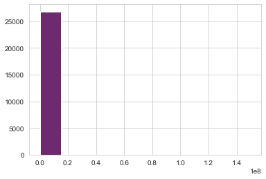

```python
df['owners_mean'].hist()
```

```python
len(df[df['owners_mean'] == df['owners_mean'].min()]['owners_mean'])
```

```
18433
```

```python
df[df['owners_mean'] == df['owners_mean'].min()]['owners_mean']
```

```
122      10000.0
124      10000.0
145      10000.0
188      10000.0
248      10000.0
          ...
27070    10000.0
27071    10000.0
27072    10000.0
27073    10000.0
27074    10000.0
Name: owners_mean, Length: 18433, dtype: float64
```

Parece que a grande maioria dos jogos nesse dataset tem, em média, 10 mil owners. Acho que vale a pena separar os dados em 3 grupos então, 1 somente com jogos com mais de 10 mil owners de média, um com todos os jogos, e outro com somente os jogos com média de 10 mil owners. Pra não atrapalhar o fluxo até agora, vou deixar pra fazer essa separação depois de ter efetuado as análises nas outras variáveis.

```python
df["average_playtime"].unique()
```

```
array([17612,   277,   187, ...,  1100,  6332,   816], dtype=int64)
```

```python
len(df["average_playtime"].unique())
```

```
1338
```

```python
df["average_playtime"].head()
```

```
0    17612
1      277
2      187
3      258
4      624
Name: average_playtime, dtype: int64
```

```python
df["average_playtime"].max()
```

```
190625
```

```python
df["average_playtime"].min()
```

```
0
```

Parece que existem jogos que foram jogados, em média, 0 horas. Acho que é uma boa ideia dar uma olhadinha neles.

```python
df[df["average_playtime"] == df["average_playtime"].min()][['name','average_playtime','median_playtime']]
```

|  | name | average_playtime | median_playtime |
| --- | --- | --- | --- |
| 26 | Rag Doll Kung Fu | 0 | 0 |
| 29 | SiN Episodes: Emergence | 0 | 0 |
| 34 | Dangerous Waters | 0 | 0 |
| 35 | Space Empires IV Deluxe | 0 | 0 |
| 36 | Disciples II: Rise of the Elves | 0 | 0 |
| ... | ... | ... | ... |
| 27070 | Room of Pandora | 0 | 0 |
| 27071 | Cyber Gun | 0 | 0 |
| 27072 | Super Star Blast | 0 | 0 |
| 27073 | New Yankee 7: Deer Hunters | 0 | 0 |
| 27074 | Rune Lord | 0 | 0 |

20709 rows × 3 columns

```python
df[df["average_playtime"] == df["average_playtime"].min()][['name','average_playtime','median_playtime']].shape
```

```
(20709, 3)
```

A grande maioria dos jogos não possui horas significativas de jogatina média ou mediana. Provavelmente não vai ajudar muito considerar o tempo de jogatina de cada jogo. Por via das dúvidas, vou criar uma coluna que apenas computa se o average_playtime é maior que 0.

```python
df["average_playtime_>0"] = df["average_playtime"].apply(lambda x: x>0).astype(int)
```

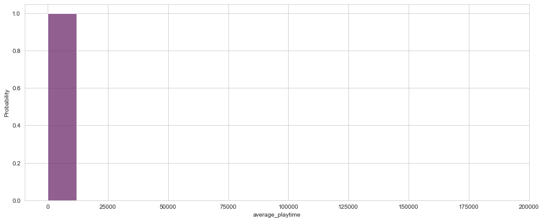

```python
ax = sns.histplot(df["average_playtime"], stat='probability')
ax.figure.set_size_inches(15,6)
```

Bom, por fim, falta avaliarmos a variável 'price'. Lembrando que os preços encontrados aqui estão em libra.

```python
df['price'].unique().round(2)
```

```
array([7.1900e+00, 3.9900e+00, 0.0000e+00, 5.7900e+00, 5.9900e+00,
       1.4990e+01, 6.9900e+00, 2.2990e+01, 4.9900e+00, 1.0990e+01,
       2.9900e+00, 4.2900e+00, 1.2990e+01, 2.4900e+00, 9.9900e+00,
       1.9900e+00, 1.5990e+01, 3.4900e+00, 2.4990e+01, 8.5900e+00,
       7.9900e+00, 4.4900e+00, 4.2500e+00, 5.5900e+00, 2.5990e+01,
       8.9900e+00, 4.7900e+00, 1.3990e+01, 8.2900e+00, 9.2900e+00,
       1.9990e+01, 1.7900e+00, 1.6990e+01, 8.6900e+00, 7.4900e+00,
       7.9000e-01, 1.6900e+00, 1.5490e+01, 1.4900e+00, 1.7990e+01,
       1.1990e+01, 3.5960e+01, 6.4900e+00, 1.5900e+00, 3.4990e+01,
       9.9000e-01, 5.1900e+00, 2.0900e+00, 2.9990e+01, 1.9980e+01,
       2.7900e+00, 2.8900e+00, 3.4950e+01, 1.2490e+01, 1.1390e+01,
       4.3900e+00, 1.8990e+01, 1.0590e+01, 6.1900e+00, 3.9990e+01,
       2.6990e+01, 3.0990e+01, 6.0000e+00, 2.3990e+01, 3.3990e+01,
       1.2390e+01, 8.4900e+00, 2.3790e+01, 1.9490e+01, 3.8990e+01,
       2.3390e+01, 6.9500e+00, 1.1490e+01, 1.8740e+01, 2.0990e+01,
       5.4900e+00, 1.3490e+01, 1.7980e+01, 2.7790e+01, 2.7110e+01,
       4.4980e+01, 1.1690e+01, 2.2900e+00, 5.4990e+01, 4.4990e+01,
       2.7000e+01, 4.6500e+00, 1.4490e+01, 1.3500e+01, 1.3590e+01,
       1.6300e+01, 1.1000e+01, 4.9990e+01, 7.5000e+00, 3.2900e+00,
       1.0290e+01, 1.7490e+01, 1.3000e+01, 4.5000e+00, 2.7990e+01,
       8.8900e+00, 4.5900e+00, 6.0990e+01, 6.6900e+00, 3.1990e+01,
       3.2990e+01, 3.6990e+01, 9.0000e+00, 3.1900e+00, 5.6900e+00,
       1.5000e+00, 2.2490e+01, 1.0000e+00, 3.5000e+00, 4.1990e+01,
       2.5790e+01, 1.3370e+01, 7.0000e+00, 3.9950e+01, 6.3500e+00,
       6.1500e+00, 1.0000e+01, 3.2000e-01, 3.2500e+01, 2.5900e+00,
       7.5000e-01, 5.9000e-01, 1.9900e+01, 4.2400e+00, 3.2300e+00,
       1.1240e+01, 4.9000e-01, 5.8000e+00, 2.7100e+01, 2.1000e+01,
       2.2800e+00, 9.0000e-01, 6.2900e+00, 6.3900e+00, 4.1200e+00,
       2.1990e+01, 6.5900e+00, 5.0000e+00, 1.8390e+01, 3.9200e+00,
       1.5000e+01, 1.8100e+01, 7.2000e-01, 1.1950e+01, 4.9500e+00,
       1.5500e+00, 2.0510e+01, 1.1750e+01, 2.6900e+00, 1.2000e+01,
       1.5499e+02, 7.2000e+00, 5.5400e+00, 4.4800e+01, 1.4690e+01,
       3.1000e+00, 4.6900e+00, 2.5000e+00, 1.6500e+00, 9.9000e+00,
       1.8490e+01, 2.3000e+00, 7.5990e+01, 2.3900e+00, 5.9500e+00,
       7.9000e+00, 7.8000e-01, 1.5900e+01, 1.6660e+01, 7.7700e+00,
       1.0490e+01, 2.0000e+00, 4.6490e+01, 7.5900e+00, 3.5900e+00,
       2.8500e+00, 1.4950e+01, 3.7900e+00, 4.7000e+00, 7.7000e+00,
       6.7900e+00, 3.7990e+01, 7.0900e+00, 1.0790e+01, 1.6740e+01,
       4.0000e+00, 2.3600e+00, 2.2400e+00, 3.5300e+00, 8.9000e-01,
       2.4000e+01, 8.0000e+00, 8.0000e-01, 2.8000e+00, 1.9500e+00,
       2.4900e+01, 7.1200e+00, 2.0700e+00, 1.2580e+01, 3.0900e+00,
       1.4300e+00, 1.4210e+01, 3.0000e+00, 5.0500e+00, 3.0400e+00,
       7.4000e-01, 1.1890e+01, 2.1300e+00, 7.7400e+00, 2.4500e+01,
       3.8900e+00, 1.1000e+00, 6.2990e+01, 7.8990e+01, 1.6800e+00,
       2.1000e+00, 1.3000e+00, 1.9000e+00, 1.1900e+01, 7.1800e+00,
       8.9000e+00, 2.1900e+00, 1.9800e+00, 2.1500e+00, 4.9900e+01,
       1.0100e+00, 6.8900e+00, 4.2199e+02, 3.0300e+00, 6.2800e+00,
       1.2890e+01, 1.4000e+01, 3.1400e+00, 8.5000e-01, 1.1400e+01,
       1.0900e+01, 1.2000e+00, 1.5800e+01, 5.3400e+00, 1.1900e+00,
       1.7000e+00, 6.9990e+01, 4.2000e+00, 2.0000e+01, 6.2000e+00,
       1.7000e+01, 1.1290e+01, 1.1500e+01, 1.1790e+01, 8.0200e+00,
       2.2600e+00, 5.3900e+00, 9.9500e+00, 1.8000e+00, 3.9800e+00,
       1.5400e+01, 6.5400e+00, 3.1500e+00, 2.3500e+00, 1.8900e+01,
       3.0200e+00, 7.4200e+00, 7.7000e-01, 2.9500e+00, 5.2000e+00,
       8.5000e+00, 6.1000e+00])
```

```python
len(df['price'].unique())
```

```
272
```

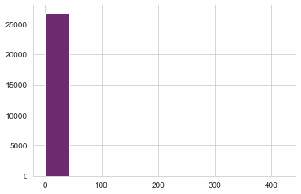

```python
df['price'].hist()
```

```python
from pingouin import normality
```

```python
normality(df['price'],method='normaltest')
```

|  | W | pval | normal |
| --- | --- | --- | --- |
| price | 44767.046882 | 0.0 | False |

```python
df['log_price'] = np.log(df['price']+1)
```

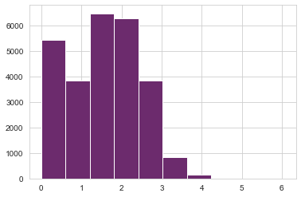

```python
df['log_price'].hist()
```

```python
df['log_log_price'] = np.log(df['log_price']+1)
```

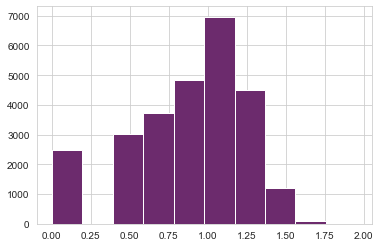

```python
df['log_log_price'].hist()
```

Agora que todas as variáveis foram avaliadas, vou exportar 3 bases diferentes, baseado na média de owners, como dito anteriormente. Farei as regressões em outro arquivo.

```python
Colunas = ['appid','name','Year','english','platforms_windows','platforms_mac','platforms_linux','genres_Action',
           'genres_Free to Play', 'genres_Strategy','genres_Adventure', 'genres_Indie', 'genres_RPG',
           'genres_Casual','genres_Simulation', 'genres_Racing', 'genres_Violent','genres_Massively Multiplayer',
           'genres_Nudity', 'genres_Sports',       'genres_Early Access', 'genres_Gore', 'genres_Sexual Content',
           'categories_Multi-player', 'categories_Online Multi-Player','categories_Local Multi-Player',
           'categories_Valve Anti-Cheat enabled','categories_Single-player', 'categories_Steam Cloud',
           'categories_Steam Achievements', 'categories_Steam Trading Cards','categories_Captions available',
           'categories_Partial Controller Support','categories_Includes Source SDK','categories_Cross-Platform Multiplayer',
           'categories_Stats','categories_Commentary available', 'categories_Includes level editor',
           'categories_Steam Workshop', 'categories_In-App Purchases','categories_Co-op',
           'categories_Full controller support','categories_Steam Leaderboards', 'categories_SteamVR Collectibles',
           'categories_Online Co-op', 'categories_Shared/Split Screen','categories_Local Co-op', 'categories_MMO',
           'categories_VR Support','categories_Mods', 'categories_Mods (require HL2)',
           'categories_Steam Turn Notifications','achievements','%_ratings','QTD_ratings','owners_mean',
           'average_playtime_>0','price','log_price','log_log_price']
```

```python
output_owners_min = df[df['owners_mean'] == df['owners_mean'].min()][Colunas]
```

```python
output_owners = df[df['owners_mean'] != df['owners_mean'].min()][Colunas]
```

```python
output_geral = df[Colunas]
```

```python
output_owners_min.to_csv('Dados Tratados/output_owners_min.csv', sep=';')
```

```python
output_owners.to_csv('Dados Tratados/output_owners.csv', sep=';')
```

```python
output_geral.to_csv('Dados Tratados/output_geral.csv', sep=';')
```

Dados tratados e discriminados, agora vamos para as regressões... no arquivo "Regressões.ipynb" dentro da mesma pasta.